# GEICO Mini Project

Giovanni Fossati

# PRELIMINARIES

## Libraries and Other Setup

Libraries needed for:

- data processing,
- visualization,
- modeling,
- and scripts with some helper functions.

```r
# data processing,
library("dplyr")
# library("tidyr")
library("lubridate")

# visualization,
library("ggplot2")
# library("scales")
# library("gridExtra")
library("MASS")

# modeling,
library("caTools")
library("ROCR")
library("caret")
library("rpart.plot")
library("tree")
library("earth")

# and scripts with some helper functions.
source("./scripts/my_functions.R")

# some settings
single_panel_mar <- c(2, 3, 2, 1)
single_panel_oma <- c(1, 2, 2, 2)
gr_par <- list( mar = single_panel_mar,
                oma = single_panel_oma,
                cex = 1.0, cex.axis = 1.01, cex.lab = 1.1,
                las = 1,
                mgp = c(1.0, 0.0, 0),
                tcl = 0.3)
gr_par_2 <- list(mar = c(3.5, 4, 2, 1),
                 oma = single_panel_oma,
                 cex = 1.0, cex.axis = 1.01, cex.lab = 1.1,
                 las = 1,
                 mgp = c(2.25, 0.25, 0),
                 tcl = 0.3)

layout_1_2 <- matrix(1:2, nrow = 2, byrow = TRUE)
layout_2_1 <- matrix(1:2, nrow = 1, byrow = TRUE)
layout_2_2_1_2 <- matrix(c(1, 1, 2, 3), nrow = 2, byrow = TRUE)
```

# THE DATA

## Loading the data set

```r
original <- read.csv(file = "data/DS_MiniProject_ANON.csv", stringsAsFactors = FALSE)
# nrow(original)
# ncol(original)

old_order <- colnames(original)

new_order <- c("Call_Flag",
               "DATE_FOR", "RTD_ST_CD", "CustomerSegment", "Tenure",
               "Age", "MART_STATUS", "GENDER",
               "CHANNEL1_6M", "CHANNEL2_6M", "CHANNEL3_6M", "CHANNEL4_6M", "CHANNEL5_6M", "PAYMENTS_6M", "METHOD1_6M",
               "CHANNEL1_3M", "CHANNEL2_3M", "CHANNEL3_3M", "CHANNEL4_3M", "CHANNEL5_3M", "PAYMENTS_3M", "METHOD1_3M",
               "RECENT_PAYMENT",
               "NOT_DI_3M", "NOT_DI_6M",
               "EVENT1_30_FLAG", "EVENT2_90_SUM",
               "LOGINS",
               "POLICYPURCHASECHANNEL")

main <- original[, new_order]
str(main)
# 'data.frame': 130086 obs. of  29 variables:
#  $ Call_Flag            : int  0 0 0 0 0 0 0 0 0 0 ...
#  $ DATE_FOR             : chr  "5/19/2014" "5/17/2014" "5/15/2014" "5/16/2014" ...
#  $ RTD_ST_CD            : chr  "ST_S0" "ST_S0" "ST_S0" "ST_S1" ...
#  $ CustomerSegment      : chr  "1" "1" "1" "1" ...
#  $ Tenure               : num  16.2 15.9 15.9 15.9 15.5 ...
#  $ Age                  : num  78.4 71 87.6 68.4 80.5 ...
#  $ MART_STATUS          : chr  "MS_S0" "MS_S1" "MS_S2" "MS_S2" ...
#  $ GENDER               : chr  "F" "F" "M" "M" ...
#  $ CHANNEL1_6M          : int  0 0 0 0 0 0 0 0 0 0 ...
#  $ CHANNEL2_6M          : int  0 6 0 0 0 0 4 6 0 0 ...
#  $ CHANNEL3_6M          : int  1 0 10 1 1 6 0 0 0 0 ...
#  $ CHANNEL4_6M          : int  0 0 0 0 0 0 0 0 0 0 ...
#  $ CHANNEL5_6M          : int  5 0 0 0 0 0 0 0 0 6 ...
#  $ PAYMENTS_6M          : int  6 6 10 1 1 6 4 6 6 6 ...
#  $ METHOD1_6M           : int  0 6 0 0 0 0 4 6 0 0 ...
#  $ CHANNEL1_3M          : int  0 0 0 0 0 0 0 0 0 0 ...
#  $ CHANNEL2_3M          : int  0 3 0 0 0 0 1 3 0 0 ...
#  $ CHANNEL3_3M          : int  1 0 6 0 1 3 0 0 0 0 ...
#  $ CHANNEL4_3M          : int  0 0 0 0 0 0 0 0 0 0 ...
#  $ CHANNEL5_3M          : int  2 0 0 0 0 0 0 0 0 3 ...
#  $ PAYMENTS_3M          : int  3 3 6 0 1 3 1 3 3 3 ...
#  $ METHOD1_3M           : int  0 3 0 0 0 0 1 3 0 0 ...
#  $ RECENT_PAYMENT       : int  0 0 0 0 0 0 0 0 0 0 ...
#  $ NOT_DI_3M            : int  0 0 0 0 0 0 0 0 0 0 ...
#  $ NOT_DI_6M            : int  0 0 0 0 0 0 0 0 0 0 ...
#  $ EVENT1_30_FLAG       : int  0 0 0 0 0 0 0 0 0 0 ...
#  $ EVENT2_90_SUM        : int  0 0 0 0 0 0 0 0 0 0 ...
#  $ LOGINS               : int  0 0 0 0 0 0 0 0 1 0 ...
#  $ POLICYPURCHASECHANNEL: int  0 0 0 1 0 0 0 0 0 0 ...
```

The data set comprises **130086** observations (customers) of **29** variables.

[output not shown]

### Modifying values of some variables

Small edit of `RTD_ST_CD` and `MART_STATUS` values (strings), for convenience:

```r
main$RTD_ST_CD <- gsub("ST_S([0-9])$", "ST_S0\\1", original$RTD_ST_CD, perl = TRUE) %>% gsub("ST_S", "ST_", .)
main$MART_STATUS <- gsub("MS_S([0-9])$", "MS_\\1", original$MART_STATUS, perl = TRUE)
```

## New Variables

Define group variables for `Age` and `Tenure` and adding them to the data set as *factor* variables:

- **Age_grp**

```r
age_breaks <- c(15, seq(25, 75, by = 5), 100)
main$Age_grp <- cut(main$Age, breaks = age_breaks, right = FALSE, include_lowest = TRUE, ordered_results = TRUE)
```

- **Tenure_grp**

```r
tenure_breaks <- c(seq(0, 20, by = 2), 30, 40, 99)
main$Tenure_grp <- cut(main$Tenure, breaks = tenure_breaks, right = FALSE, include_lowest = TRUE, ordered_results = TRUE)
```

- **Nch_6M** : The number of different channels used by a customer in the last 6 months

```r
main$Nch_6M <- apply(main[, grep("^CH.*_6M", colnames(main))], 1, function(x) {sum(x > 0, na.rm = TRUE)})
Nch_6M_by_customer <- main$Nch_6M
```

- **Nch_3M** : The number of different channels used by a customer in the last 3 months

```r
main$Nch_3M <- apply(main[, grep("^CH.*_3M", colnames(main))], 1, function(x) {sum(x > 0, na.rm = TRUE)})
Nch_3M_by_customer <- main$Nch_3M
```

## Checking *Missing Data*

```r
check_NAs <- sapply(main, function(x) {sum(is.na(x))})
tmp_df <- data.frame(Variable = names(check_NAs),
                     Number_of_NA = check_NAs,
                     row.names = NULL,
                     stringsAsFactors = FALSE)

kable(tmp_df[check_NAs > 0, ])
```

|  | Variable | Number_of_NA |
| --- | --- | --- |
| 9 | CHANNEL1_6M | 809 |
| 10 | CHANNEL2_6M | 809 |
| 11 | CHANNEL3_6M | 809 |
| 12 | CHANNEL4_6M | 809 |
| 13 | CHANNEL5_6M | 809 |
| 14 | PAYMENTS_6M | 809 |
| 15 | METHOD1_6M | 809 |
| 23 | RECENT_PAYMENT | 809 |

Only eight variables have *missing values*, and they are all associated with *payments in the last 6 months*.  
In fact, all `NA` are the concentrated in the same 809 customers, for whom there are not data for all their `_6M` variables, as well as for `RECENT_PAYMENT`

```r
check_NA_by_row <- apply(main, 1, function(x) sum(is.na(x)))
table(check_NA_by_row)
# check_NA_by_row
#      0      8
# 129277    809
```

- These may be very new customers?  
  No, looking at `Tenure` would seem to show that they may be a random subset of the general customer population.
- **More imputation ideas?**

## IMPUTATION

A simple strategy for imputation of missing values of variable (e.g. `PAYMENTS_6M`) is to sample the distribution of the known values for customers with similar characteristics. A simple definition of similarity could be based on matching values of another relevant variable: for `PAYMENTS_6M` this latter could be `PAYMENTS_3M`.

We are going to impute missing values of `x_6M` for a customer with `x_3M = n` sampling the distribution of `x_6M` for the subset of customers with `x_3M = n`.

First step is the preparation of a reduced and cleaned (i.e. without `NA`) dataset to compute statistics of the existing values to be used for imputation. With this dataset, we compute contingency tables for pairs of matching `_3M` and `_6M` variables (e.g. `CHANNEL1_3M`, `CHANNEL1_6M`) and from these tables of probabilities for the `x_6M` values at a fixed `x_3M` value (basically normalizing each entry on a row by the sum of the counts that row).

```r
df.clean <- main[!is.na(main$PAYMENTS_6M), grep("^[CMP].*_[36]M$", colnames(main))]

# prepares stats (tables) for "prediction" of missing values.
var_vec <- colnames(main)[grep("^[PCM].*_3M", colnames(main))] %>% gsub("_3M", "", .)
tab_list <- list()
for(var in var_vec) {
    v3M <- paste0(var, "_3M")
    v6M <- paste0(var, "_6M")
    i_str_n <- paste0(var, "_n")
    i_str_p <- paste0(var, "_p")

    tmp_t <- table(df.clean[, v3M], df.clean[, v6M])
    tmp_p <- tmp_t/matrix(rep(rowSums(tmp_t), each = ncol(tmp_t)), ncol = ncol(tmp_t), byrow = TRUE)
    tab_list[[i_str_n]] <- tmp_t
    tab_list[[i_str_p]] <- tmp_p
}
```

As an example, this is the count table for the `CHANNEL1` variables (rows and columns for `3M` and `6M` values respectively):

```r
tab_list[["CHANNEL1_n"]]
#
#          0      1      2      3      4      5      6      7      8      9     10     11     12
#   0 120095   1041   1117    616    187     68     19      0      0      0      0      0      0
#   1      0    618    176    297    568     92     16     13      0      1      0      0      0
#   2      0      0    331    194    301    715    104     36     15      0      0      0      0
#   3      0      0      0    157    141    375   1284    131     37     14      0      0      0
#   4      0      0      0      0     25     30     83    163     58     29     12      0      0
#   5      0      0      0      0      0      2      6     15     25     21     13      6      0
#   6      0      0      0      0      0      0      1      1      6      5      8      4      5
```

and this is the corresponding probability table:

```r
round(tab_list[["CHANNEL1_p"]], 3)
#
#         0     1     2     3     4     5     6     7     8     9    10    11    12
#   0 0.975 0.008 0.009 0.005 0.002 0.001 0.000 0.000 0.000 0.000 0.000 0.000 0.000
#   1 0.000 0.347 0.099 0.167 0.319 0.052 0.009 0.007 0.000 0.001 0.000 0.000 0.000
#   2 0.000 0.000 0.195 0.114 0.177 0.422 0.061 0.021 0.009 0.000 0.000 0.000 0.000
#   3 0.000 0.000 0.000 0.073 0.066 0.175 0.600 0.061 0.017 0.007 0.000 0.000 0.000
#   4 0.000 0.000 0.000 0.000 0.062 0.075 0.208 0.408 0.145 0.072 0.030 0.000 0.000
#   5 0.000 0.000 0.000 0.000 0.000 0.023 0.068 0.170 0.284 0.239 0.148 0.068 0.000
#   6 0.000 0.000 0.000 0.000 0.000 0.000 0.033 0.033 0.200 0.167 0.267 0.133 0.167
```

The actual imputation is done as follows:

```r
# subset of data needing imputation
df.to_impute <- main[, grep("^[CMP].*_[36]M$", colnames(main))] %>% filter( . , is.na(PAYMENTS_6M))

set.seed(9898)
imputed_values <- list()
for(var in var_vec) {
    v3M <- paste0(var, "_3M")
    v6M <- paste0(var, "_6M")
    i_str_n <- paste0(var, "_n")
    i_str_p <- paste0(var, "_p")

    values <- as.integer(dimnames(tab_list[[i_str_n]])[[2]])
    imputed_values[[v6M]] <- sample(values, nrow(df.to_impute), replace = TRUE, tab_list[[i_str_p]]["0", ])
}
df.imputed_values <- as.data.frame(imputed_values)

main.imputed <- main
for(var in var_vec) {
    v6M <- paste0(var, "_6M")
    main.imputed[is.na(main.imputed[, v6M]), v6M] <- df.imputed_values[, v6M]
}
```

One last variable needs imputation, `RECENT_PAYMENT`, which is binary-valued. Because for all customers with `RECENT_PAYMENT == NA` the `PAYMENTS_3M = 0`, we can fill the missing values with 0s.

```r
main.imputed$RECENT_PAYMENT[is.na(main$RECENT_PAYMENT)] <- 0
```

The dataset with imputed missing values is stored in the separate dataframe `main.imputed`.

# EXPLORATORY DATA ANALYSIS

## Demographics Variables

### Age

| Min. | 1st Qu. | Median | Mean | 3rd Qu. | Max. |
| --- | --- | --- | --- | --- | --- |
| 16.69 | 37.88 | 49.15 | 48.84 | 58.86 | 99.35 |

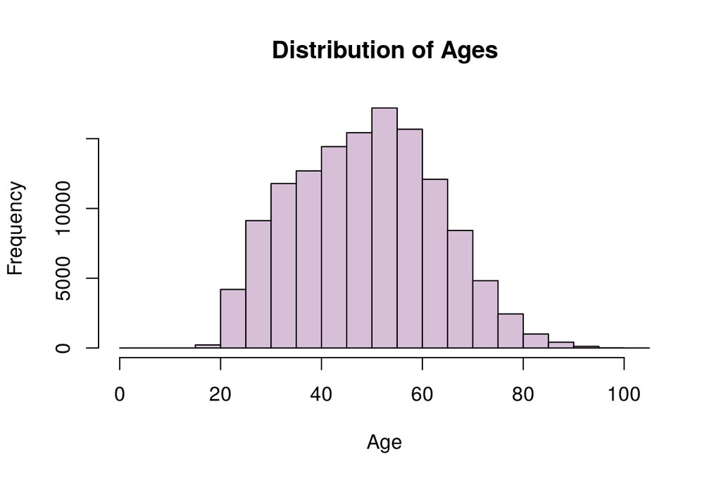

### Tenure

| Min. | 1st Qu. | Median | Mean | 3rd Qu. | Max. |
| --- | --- | --- | --- | --- | --- |
| 0.03285 | 3.25 | 7.006 | 8.583 | 11.61 | 63.09 |

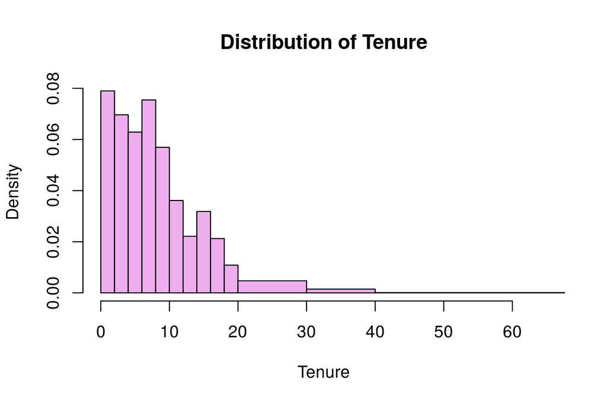

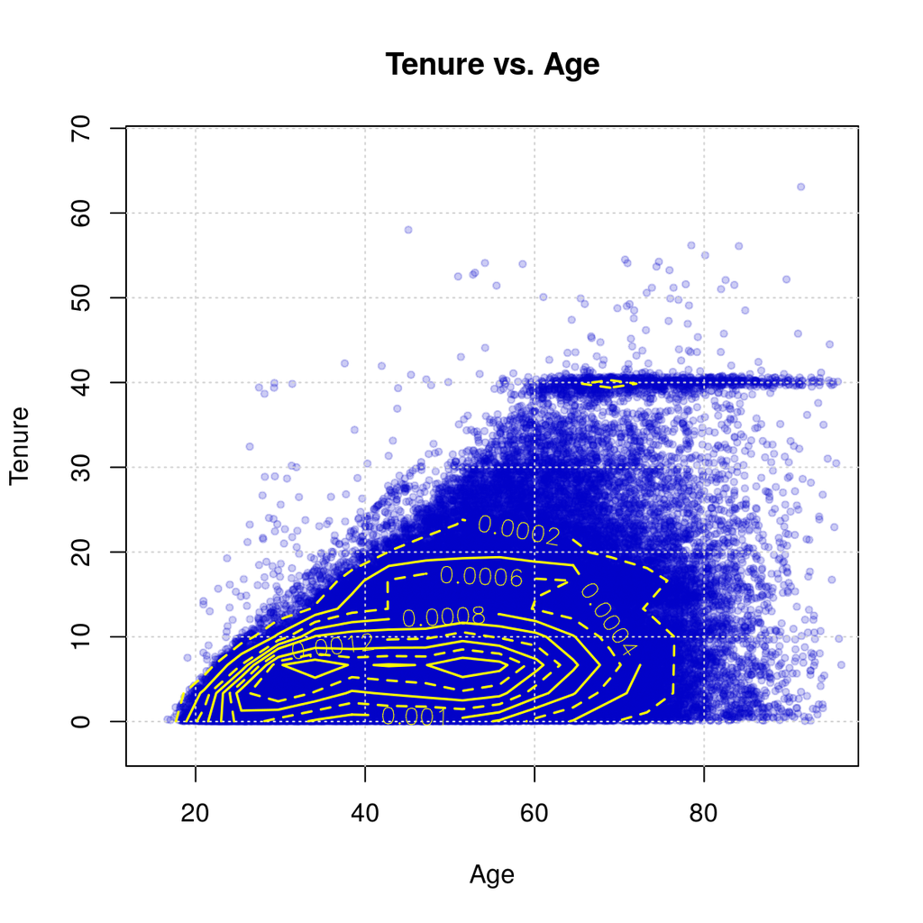

```r
x <- main$Age
y <- main$Tenure
z <- kde2d(x, y, n = 20)
plot(x, y,
     xlim = c(15, 95),
     ylim = c(0, 65),
     pch = 19, col = rgb(0, 0, 0.8, 0.20), cex = 0.6,
     xlab = "Age",
     ylab = "Tenure",
     main = "Tenure vs. Age",
     asp = 1.0)
grid()
contour(z, drawlabels = TRUE,
        # levels = zlevels,
        labcex = 1.0,
        lty = c(1, 2, 1, 2, 1),
        lwd = 1.5,
        col = "yellow",
        add = TRUE)
```

- **NOTE**: what is that odd “bar” at `Tenure ~= 40` and `Age ~ 60 - 95`?  
  Customers acquired from some acquisition?

### Marital Status

Counts by Marital Status Categories

|  | MS_0 | MS_1 | MS_2 | MS_3 | MS_4 |
| --- | --- | --- | --- | --- | --- |
| counts | 4853 | 45717 | 58164 | 13446 | 7906 |
| fraction | 0.037 | 0.351 | 0.447 | 0.103 | 0.061 |

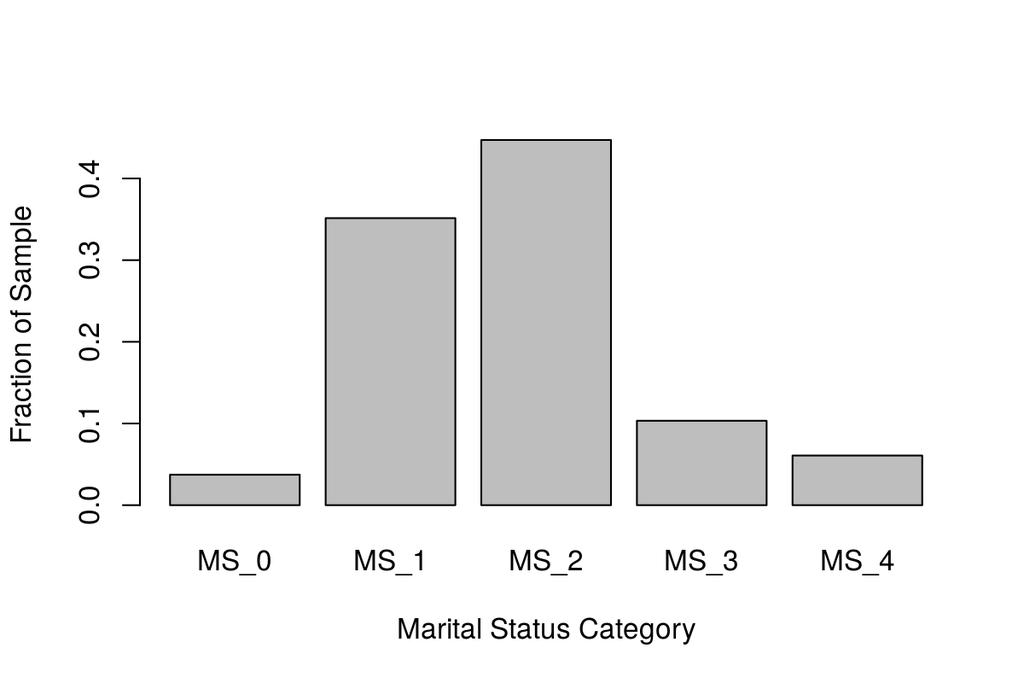

### Gender

Counts by Gender

|  | F | M |
| --- | --- | --- |
| counts | 60177 | 69909 |
| fraction | 0.463 | 0.537 |

## Payments Channels

### “6M” Variables

#### 6M : By Channel

```r
N_customers_by_channel_6M <- sapply(main[, grep("^CH.*_6M", colnames(main))], function(x) {sum(x > 0, na.rm = TRUE)})
N_times_by_channel_6M <- sapply(main[, grep("^CH.*_6M", colnames(main))], function(x) {sum(x, na.rm = TRUE)})

kable(rbind(N_customers_by_channel_6M, N_times_by_channel_6M,
            Average = sprintf("%.2f", N_times_by_channel_6M/N_customers_by_channel_6M)),
      digits = 3, align = c("r"),
      caption = "Channels Usage (6M)")
```

Channels Usage (6M)

|  | CHANNEL1_6M | CHANNEL2_6M | CHANNEL3_6M | CHANNEL4_6M | CHANNEL5_6M |
| --- | --- | --- | --- | --- | --- |
| N_customers_by_channel_6M | 9182 | 34429 | 26405 | 26016 | 17205 |
| N_times_by_channel_6M | 33846 | 122615 | 104928 | 51868 | 73665 |
| Average | 3.69 | 3.56 | 3.97 | 1.99 | 4.28 |

Number of different channels used by customers (6M)

|  | count | fraction |
| --- | --- | --- |
| 0 | 42114 | 0.324 |
| 1 | 65430 | 0.503 |
| 2 | 19898 | 0.153 |
| 3 | 2565 | 0.020 |
| 4 | 79 | 0.001 |

#### 6M : Total Payments

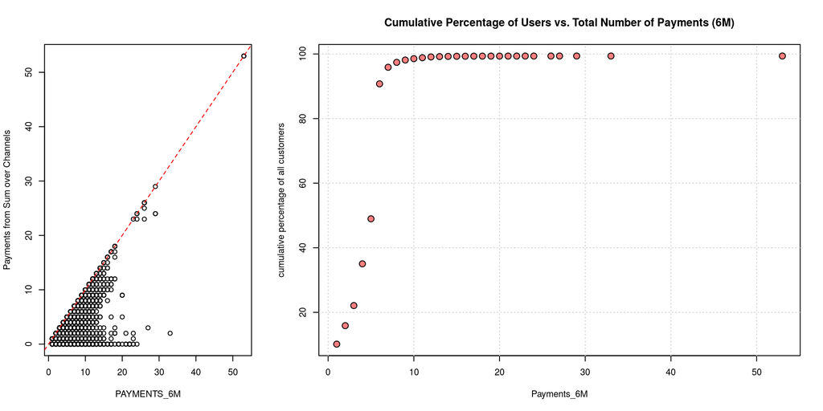

- Number of customers for whom the sum the `CHANNEL*_6M` values matches `PAYMENTS_6M`: **69511**
- Total number of `PAYMENTS_6M` for customers whose payments are all accounted for in CHANNELS : **331565**
- Total number of `PAYMENTS_6M` for customers with more payments than in CHANNELS : **295213**
- Comparison between Total Payments and payments from Channels:

```r
tmp <- table(main$Nch_6M, main$PAYMENTS_6M == Npay_6M_by_customer)
tmp <- cbind(tmp, rowSums(tmp), tmp[, 2]/rowSums(tmp)*100)
round(tmp, 3)
#   FALSE  TRUE
# 0 41305     0 41305  0.000
# 1 14252 51178 65430 78.218
# 2  3757 16141 19898 81.119
# 3   436  2129  2565 83.002
# 4    16    63    79 79.747
```

For customers who used some of these 5 channels, payments done over those cover about 80% of all their payments

#### 6M : Method1 Payments

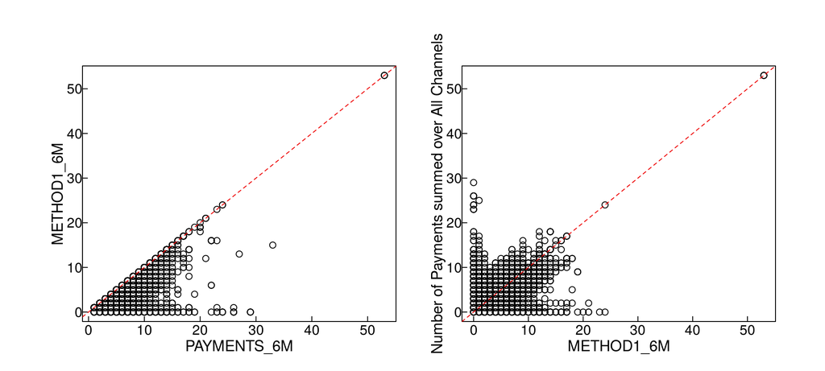

### “3M” Variables

#### 3M : By Channel

```r
N_customers_by_channel_3M <- sapply(main[, grep("^CH.*_3M", colnames(main))], function(x) {sum(x > 0, na.rm = TRUE)})
N_times_by_channel_3M <- sapply(main[, grep("^CH.*_3M", colnames(main))], function(x) {sum(x, na.rm = TRUE)})

kable(rbind(N_customers_by_channel_3M, N_times_by_channel_3M,
            Average = sprintf("%.2f", N_times_by_channel_3M/N_customers_by_channel_3M)),
      digits = 3, align = c("r"),
      caption = "Channels Usage (3M)")
```

Channels Usage (3M)

|  | CHANNEL1_3M | CHANNEL2_3M | CHANNEL3_3M | CHANNEL4_3M | CHANNEL5_3M |
| --- | --- | --- | --- | --- | --- |
| N_customers_by_channel_3M | 6134 | 28365 | 22517 | 16185 | 14994 |
| N_times_by_channel_3M | 13810 | 61698 | 52777 | 25582 | 36887 |
| Average | 2.25 | 2.18 | 2.34 | 1.58 | 2.46 |

```r
tmp <- table(main$Nch_3M)

kable(as.data.frame(cbind(count = tmp,
                          fraction = sprintf("%.3f", tmp/nrow(main)))), digits = 3, align = "r",
                          caption = "Number of different channels used by customers (3M)")
```

Number of different channels used by customers (3M)

|  | count | fraction |
| --- | --- | --- |
| 0 | 54252 | 0.417 |
| 1 | 64064 | 0.492 |
| 2 | 11191 | 0.086 |
| 3 | 567 | 0.004 |
| 4 | 12 | 0.000 |

#### 3M : Total Payments

- **NOTE**: Outliers!

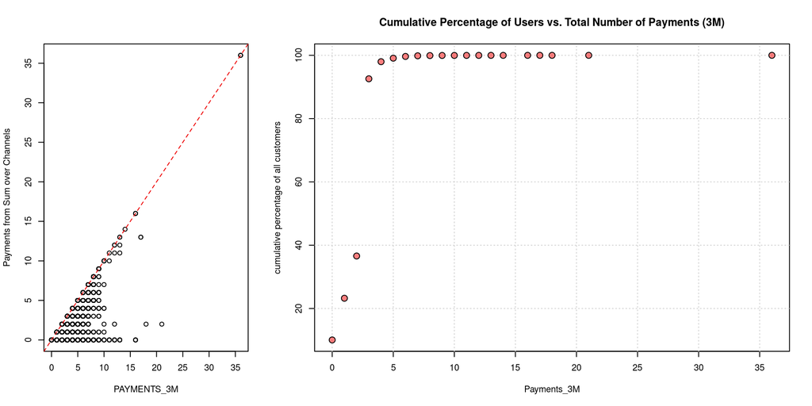

```r
tmp <- table(main$Nch_3M, main$PAYMENTS_3M == Npay_3M_by_customer)
tmp <- cbind(tmp, rowSums(tmp), tmp[, 2]/rowSums(tmp)*100)
round(tmp, 3)
#   FALSE  TRUE
# 0 41158 13094 54252  24.136
# 1  8572 55492 64064  86.620
# 2  1076 10115 11191  90.385
# 3    40   527   567  92.945
# 4     0    12    12 100.000
```

#### 3M : METHOD1

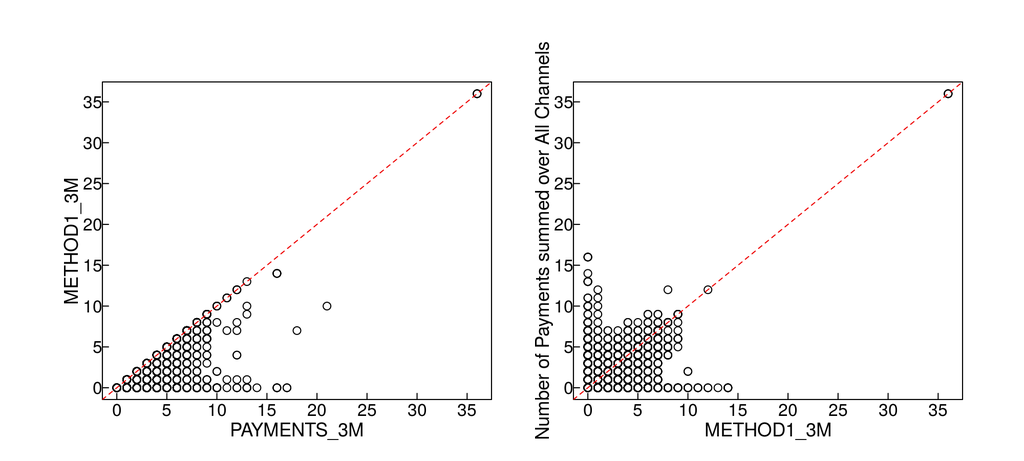

### Comparison b/w 3M and 6M Payments

As expected, the count over the last 6 months is larger than over the last 3 months, a minimal health check of the dataset.

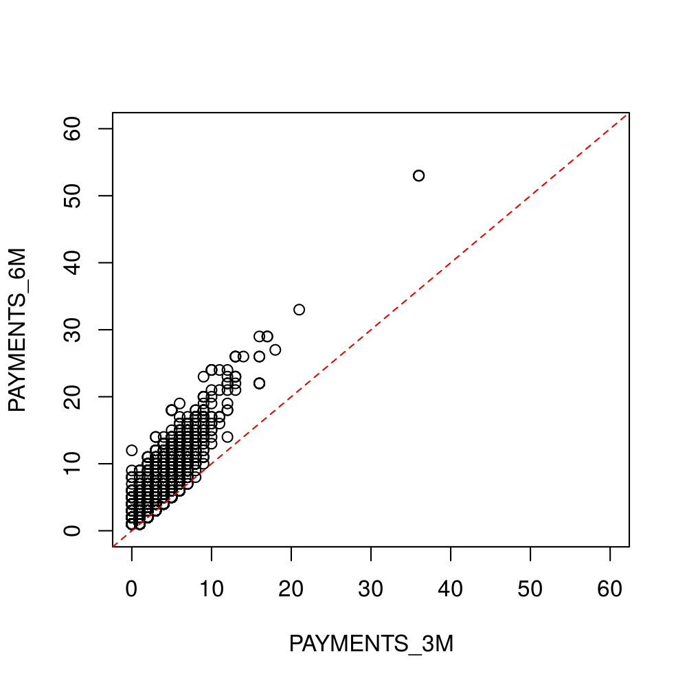

### Census of Other Variables

RECENT_PAYMENT (0/1 flag)

|  | 0 | 1 |
| --- | --- | --- |
| counts | 115615 | 13662 |
| fraction | 0.889 | 0.105 |

NOT_DI_3M (0/1 flag)

|  | 0 | 1 |
| --- | --- | --- |
| counts | 122844 | 7242 |
| fraction | 0.944 | 0.056 |

NOT_DI_6M (0/1 flag)

|  | 0 | 1 |
| --- | --- | --- |
| counts | 119678 | 10408 |
| fraction | 0.920 | 0.080 |

NOT_DI_3M & NOT_DI_6M

|  | 0 | 1 |
| --- | --- | --- |
| 0 | 119678 | 3166 |
| 1 | 0 | 7242 |

EVENT1_30_FLAG (0/1 flag)

| Var1 | Freq |
| --- | --- |
| 0 | 130086 |

EVENT2_90_SUM

|  | 0 | 1 | 2 | 3 | 4 |
| --- | --- | --- | --- | --- | --- |
| counts | 111226 | 12984 | 5472 | 392 | 12 |
| fraction | 0.855 | 0.100 | 0.042 | 0.003 | 0.000 |

LOGINS (grouped)

|  | 0 | 1 | 2 | 3 | 4+ |
| --- | --- | --- | --- | --- | --- |
| counts | 76248 | 27330 | 13149 | 5973 | 7386 |
| fraction | 0.586 | 0.210 | 0.101 | 0.046 | 0.057 |

POLICYPURCHASECHANNEL (0/1 flag)

|  | 0 | 1 |
| --- | --- | --- |
| counts | 113087 | 16999 |
| fraction | 0.869 | 0.131 |

## Outcome Variable vs. the Predictors

```r
table(main$Call_Flag)
#
#      0      1
# 125322   4764
```

- Overall percentage that made a service payment call (BASELINE RATE) : **3.662**.
- **The dataset is quite unbalanced from the point of the view of the outcome variable**.

#### vs. PURCHASECHANNEL

POLICYPURCHASECHANNEL

|  | 0 | 1 | tot | fraction | pct_of_1 | pct_unc |
| --- | --- | --- | --- | --- | --- | --- |
| 0 | 108622 | 4465 | 113087 | 0.869 | 3.948 | 0.058 |
| 1 | 16700 | 299 | 16999 | 0.131 | 1.759 | 0.101 |

#### vs. RECENT_PAYMENT

RECENT_PAYMENT

|  | 0 | 1 | tot | fraction | pct_of_1 | pct_unc |
| --- | --- | --- | --- | --- | --- | --- |
| 0 | 111109 | 4506 | 115615 | 0.889 | 3.897 | 0.057 |
| 1 | 13443 | 219 | 13662 | 0.105 | 1.603 | 0.107 |

#### vs. DATE_FOR

DATE_FOR

|  | 0 | 1 | tot | fraction | pct_of_1 | pct_unc |
| --- | --- | --- | --- | --- | --- | --- |
| 5/13/2014 | 14613 | 641 | 15254 | 0.117 | 4.202 | 0.162 |
| 5/14/2014 | 16236 | 648 | 16884 | 0.130 | 3.838 | 0.148 |
| 5/15/2014 | 15986 | 638 | 16624 | 0.128 | 3.838 | 0.149 |
| 5/16/2014 | 15905 | 665 | 16570 | 0.127 | 4.013 | 0.152 |
| 5/17/2014 | 15431 | 622 | 16053 | 0.123 | 3.875 | 0.152 |
| 5/18/2014 | 16367 | 635 | 17002 | 0.131 | 3.735 | 0.145 |
| 5/19/2014 | 16171 | 533 | 16704 | 0.128 | 3.191 | 0.136 |
| 5/20/2014 | 14613 | 382 | 14995 | 0.115 | 2.548 | 0.129 |

**NOTE about barplot colors**: in this and all following barplots, colors are coded on the difference between the call percentage values and the **base rate**:

- **grey** if the difference is less than $2\sigma$, where the $\sigma$ is that of the value not of the *base rate*.
- **green** if the value is more than $2\sigma$ **larger** than the *base rate*.
- **red** if the value is more than $2\sigma$ **smaller** than the *base rate*.

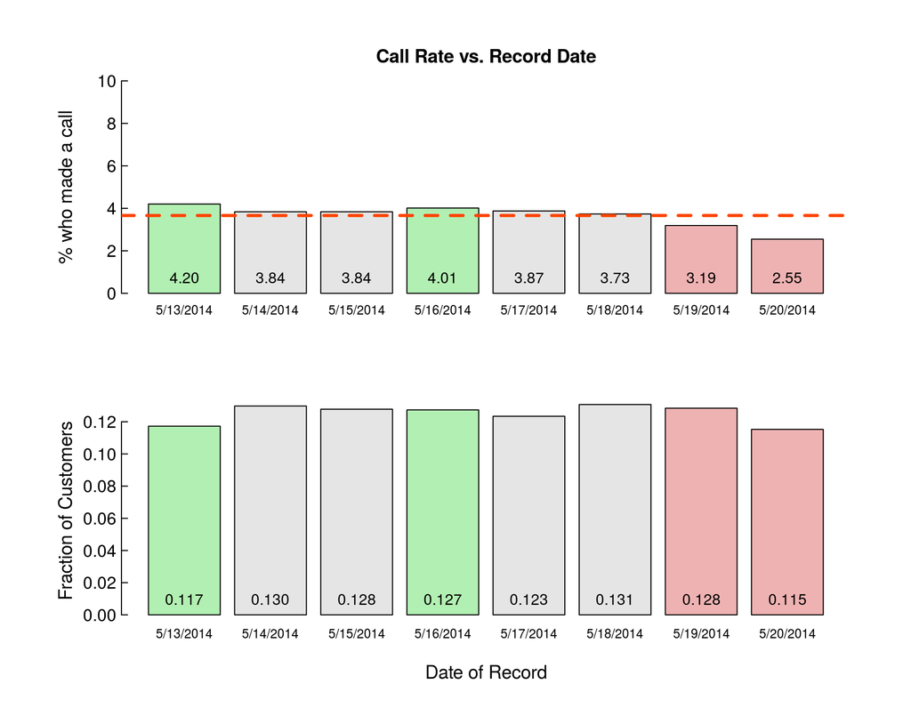

```r
par(gr_par_2)
layout(layout_1_2)
bp_col <- get_colors_vector(values = tmp[, 5], sd = tmp[, 6], nsigma = 2)

bp_x <- barplot(tmp[, 5], ylim = ylim_pct, col = bp_col, xlab = "", ylab = "% who made a call", cex.names = 0.75)
abline(base_rate, 0, lty = 2, col = "orangered", lwd = 3)
text(bp_x, bp_text_offset_pct, labels = sprintf("%.2f", tmp[, 5]), pos = 3, cex = 0.9)

barplot(tmp[, 3]/sum(tmp[, 3]), col = bp_col,
        xlab = "Date of Record", ylab = "Fraction of Customers", cex.names = 0.75)
text(bp_x, 0.0, labels = sprintf("%.3f", tmp[, 4]), pos = 3, cex = 0.9)

par(fig = c(0, 1, 0, 1), mar = c(5, 4, 4, 1)+0.1, cex.axis = 1.0)
title("Call Rate vs. Record Date", cex.main = 1.1, outer = FALSE, line = 3)
```

#### vs. Rated State

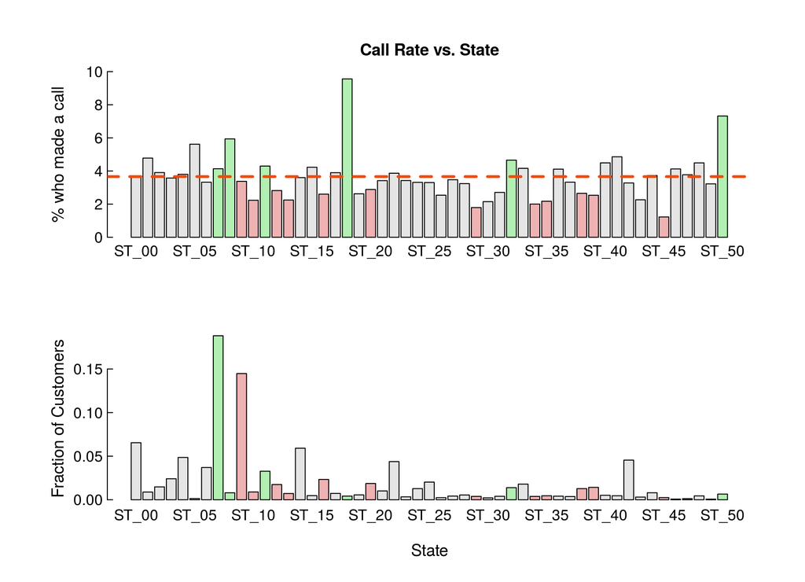

```r
par(gr_par_2)
layout(layout_1_2)
bp_col <- get_colors_vector(values = tmp[, 5], sd = tmp[, 6], nsigma = 2)

bp_x <- barplot(tmp[, 5], ylim = ylim_pct, col = bp_col, xlab = "", ylab = "% who made a call")
abline(base_rate, 0, lty = 2, col = "orangered", lwd = 3)

barplot(tmp[, 3]/sum(tmp[, 3]), xlab = "State", ylab = "Fraction of Customers", col = bp_col)
#
par(fig = c(0, 1, 0, 1), mar = c(5, 4, 4, 1)+0.1, cex.axis = 1.0)
title("Call Rate vs. State", cex.main = 1.1, outer = FALSE, line = 3)
```

#### vs. CustomerSegment

CustomerSegment

|  | 0 | 1 | tot | fraction | pct_of_1 | pct_unc |
| --- | --- | --- | --- | --- | --- | --- |
| 1 | 92658 | 3227 | 95885 | 0.737 | 3.365 | 0.058 |
| 2 | 24247 | 1187 | 25434 | 0.196 | 4.667 | 0.132 |
| 3 | 4817 | 248 | 5065 | 0.039 | 4.896 | 0.303 |
| NONE | 3600 | 102 | 3702 | 0.028 | 2.755 | 0.269 |

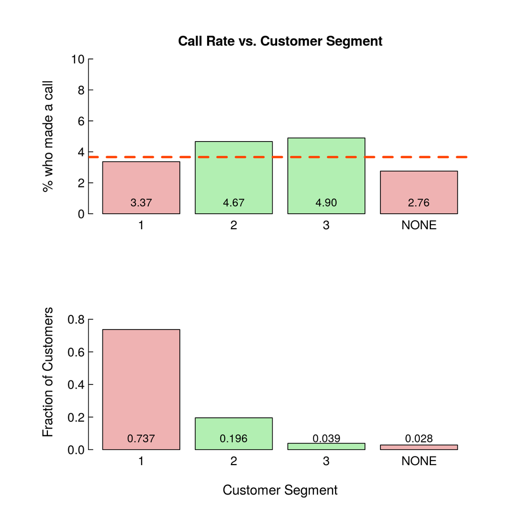

```r
par(gr_par_2)
layout(layout_1_2)
bp_col <- get_colors_vector(values = tmp[, 5], sd = tmp[, 6], nsigma = 2)

bp_x <- barplot(tmp[, 5], ylim = ylim_pct, col = bp_col, xlab = "", ylab = "% who made a call")
abline(base_rate, 0, lty = 2, col = "orangered", lwd = 3)
text(bp_x, bp_text_offset_pct, labels = sprintf("%.2f", tmp[, 5]), pos = 3, cex = 0.9)

barplot(tmp[, 3]/sum(tmp[, 3]), ylim = ylim_frac, col = bp_col,
        xlab = "Customer Segment", ylab = "Fraction of Customers")
text(bp_x, bp_text_offset_frac, labels = sprintf("%.3f", tmp[, 4]), pos = 3, cex = 0.9)

par(fig = c(0, 1, 0, 1), mar = c(5, 4, 4, 1)+0.1, cex.axis = 1.0)
title("Call Rate vs. Customer Segment", cex.main = 1.1, outer = FALSE, line = 3)
```

#### vs. NOT_DI_3M (enrolled in automated payments in last 3 months)

|  | 0 | 1 | tot | fraction | pct_of_1 | pct_unc |
| --- | --- | --- | --- | --- | --- | --- |
| 0 | 118545 | 4299 | 122844 | 0.944 | 3.500 | 0.052 |
| 1 | 6777 | 465 | 7242 | 0.056 | 6.421 | 0.288 |

#### vs. NOT_DI_6M (enrolled in automated payments in last 6 months)

NOT_DI_6M

|  | 0 | 1 | tot | fraction | pct_of_1 | pct_unc |
| --- | --- | --- | --- | --- | --- | --- |
| 0 | 115481 | 4197 | 119678 | 0.92 | 3.507 | 0.053 |
| 1 | 9841 | 567 | 10408 | 0.08 | 5.448 | 0.222 |

#### vs. EVENT1_30_FLAG

EVENT1_30_FLAG

|  | 0 | 1 | tot | fraction | pct_of_1 | pct_unc |
| --- | --- | --- | --- | --- | --- | --- |
| 0 | 125322 | 4764 | 130086 | 1 | 3.662 | 0.052 |

- Since `EVENT1_30_FLAG` is 0 for all customers, this variable carries no predictive power.

#### vs. EVENT2_90_SUM

EVENT2_90_SUM

|  | 0 | 1 | tot | fraction | pct_of_1 | pct_unc |
| --- | --- | --- | --- | --- | --- | --- |
| 0 | 107081 | 4145 | 111226 | 0.855 | 3.727 | 0.057 |
| 1 | 12596 | 388 | 12984 | 0.100 | 2.988 | 0.149 |
| 2 | 5256 | 216 | 5472 | 0.042 | 3.947 | 0.263 |
| 3 | 377 | 15 | 392 | 0.003 | 3.827 | 0.969 |
| 4 | 12 | 0 | 12 | 0.000 | 0.000 | 0.000 |

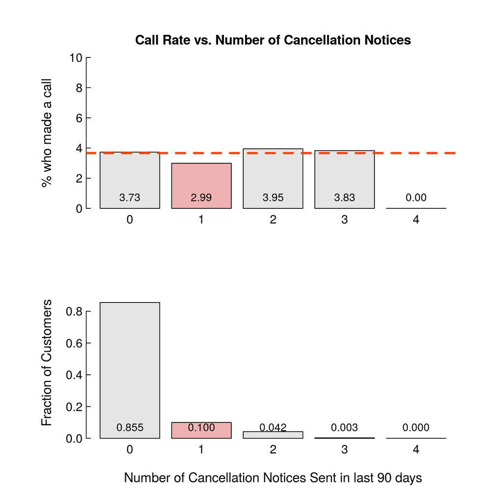

```r
par(gr_par_2)
layout(layout_1_2)
bp_col <- get_colors_vector(values = tmp[, 5], sd = tmp[, 6], nsigma = 2)

bp_x <- barplot(tmp[, 5], ylim = ylim_pct, col = bp_col, xlab = "", ylab = "% who made a call")
abline(base_rate, 0, lty = 2, col = "orangered", lwd = 3)
text(bp_x, bp_text_offset_pct, labels = sprintf("%.2f", tmp[, 5]), pos = 3, cex = 0.9)

barplot(tmp[, 3]/sum(tmp[, 3]), ylim = ylim_frac, col = bp_col,
        xlab = "Number of Cancellation Notices Sent in last 90 days",
        ylab = "Fraction of Customers")
text(bp_x, bp_text_offset_frac, labels = sprintf("%.3f", tmp[, 4]), pos = 3, cex = 0.9)

par(fig = c(0, 1, 0, 1), mar = c(5, 4, 4, 1)+0.1, cex.axis = 1.0)
title("Call Rate vs. Number of Cancellation Notices", cex.main = 1.1, outer = FALSE, line = 3)
```

#### vs. LOGINS

LOGINS

|  | 0 | 1 | tot | fraction | pct_of_1 | pct_unc |
| --- | --- | --- | --- | --- | --- | --- |
| 0 | 72126 | 4122 | 76248 | 0.586 | 5.406 | 0.082 |
| 1 | 26964 | 366 | 27330 | 0.210 | 1.339 | 0.070 |
| 2 | 13020 | 129 | 13149 | 0.101 | 0.981 | 0.086 |
| 3+ | 13212 | 147 | 13359 | 0.103 | 1.100 | 0.090 |

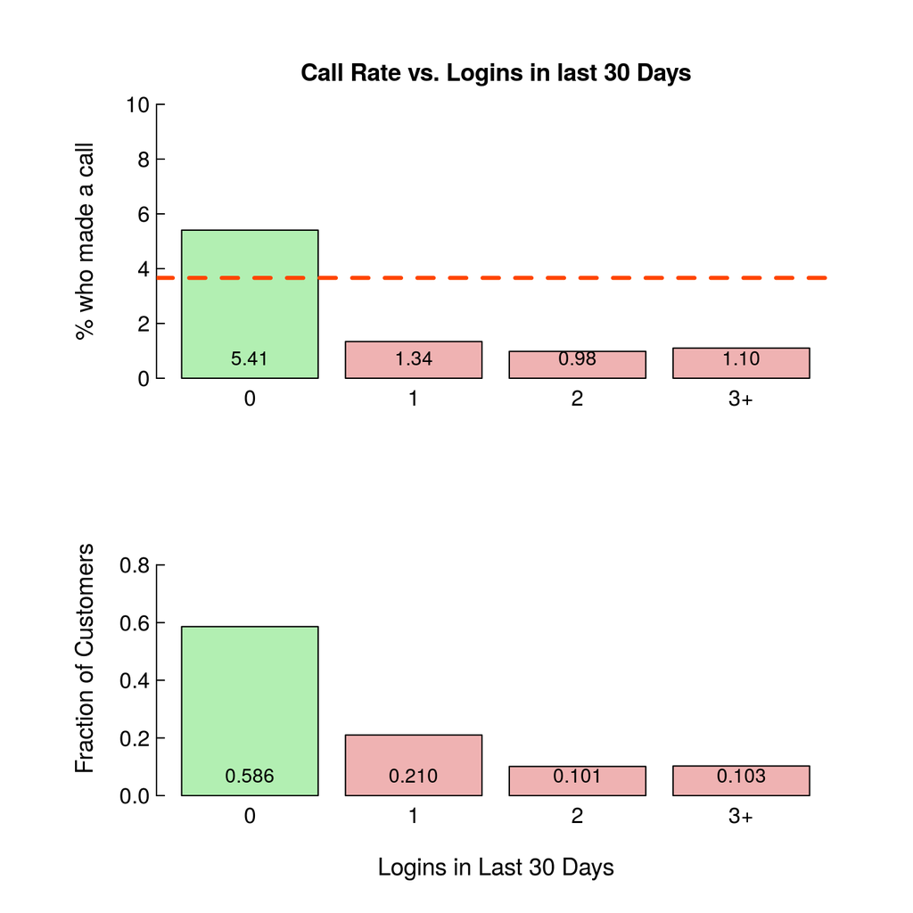

```r
par(gr_par_2)
layout(layout_1_2)
bp_col <- get_colors_vector(values = tmp[, 5], sd = tmp[, 6], nsigma = 2)

bp_x <- barplot(tmp[, 5], ylim = ylim_pct, col = bp_col, xlab = "", ylab = "% who made a call")
abline(base_rate, 0, lty = 2, col = "orangered", lwd = 3)
text(bp_x, bp_text_offset_pct, labels = sprintf("%.2f", tmp[, 5]), pos = 3, cex = 0.9)

barplot(tmp[, 3]/sum(tmp[, 3]), ylim = ylim_frac, col = bp_col,
        xlab = "Logins in Last 30 Days", ylab = "Fraction of Customers")
text(bp_x, bp_text_offset_frac, labels = sprintf("%.3f", tmp[, 4]), pos = 3, cex = 0.9)

par(fig = c(0, 1, 0, 1), mar = c(5, 4, 4, 1)+0.1, cex.axis = 1.0)
title("Call Rate vs. Logins in last 30 Days", cex.main = 1.1, outer = FALSE, line = 3)
```

#### vs. GENDER

GENDER

|  | 0 | 1 | tot | fraction | pct_of_1 | pct_unc |
| --- | --- | --- | --- | --- | --- | --- |
| F | 58079 | 2098 | 60177 | 0.463 | 3.486 | 0.075 |
| M | 67243 | 2666 | 69909 | 0.537 | 3.814 | 0.072 |

#### vs. Marital Status

MART_STATUS

|  | 0 | 1 | tot | fraction | pct_of_1 | pct_unc |
| --- | --- | --- | --- | --- | --- | --- |
| MS_0 | 4621 | 232 | 4853 | 0.037 | 4.781 | 0.306 |
| MS_1 | 43927 | 1790 | 45717 | 0.351 | 3.915 | 0.091 |
| MS_2 | 56307 | 1857 | 58164 | 0.447 | 3.193 | 0.073 |
| MS_3 | 12908 | 538 | 13446 | 0.103 | 4.001 | 0.169 |
| MS_4 | 7559 | 347 | 7906 | 0.061 | 4.389 | 0.230 |

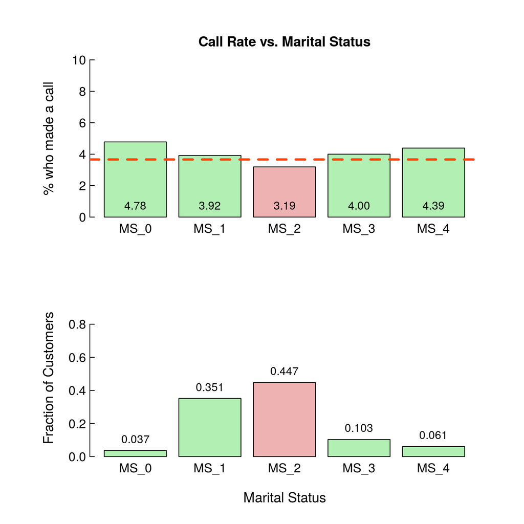

```r
par(gr_par_2)
layout(layout_1_2)
bp_col <- get_colors_vector(values = tmp[, 5], sd = tmp[, 6], nsigma = 2)

bp_x <- barplot(tmp[, 5], ylim = ylim_pct, col = bp_col, xlab = "", ylab = "% who made a call")
abline(base_rate, 0, lty = 2, col = "orangered", lwd = 3)
text(bp_x, bp_text_offset_pct, labels = sprintf("%.2f", tmp[, 5]), pos = 3, cex = 0.9)

barplot(tmp[, 3]/sum(tmp[, 3]), ylim = ylim_frac, col = bp_col,
        xlab = "Marital Status", ylab = "Fraction of Customers")
text(bp_x, tmp[, 4] + bp_text_offset_frac, labels = sprintf("%.3f", tmp[, 4]), pos = 3, cex = 0.9)

par(fig = c(0, 1, 0, 1), mar = c(5, 4, 4, 1)+0.1, cex.axis = 1.0)
title("Call Rate vs. Marital Status", cex.main = 1.1, outer = FALSE, line = 3)
```

#### vs. Number of Different Channels used by Customer (6M)

Call Rate vs. Number of Different Channels used by Customer (6M)

|  | 0 | 1 | tot | fraction | pct_of_1 | pct_unc |
| --- | --- | --- | --- | --- | --- | --- |
| 0 | 41625 | 489 | 42114 | 0.324 | 1.161 | 0.052 |
| 1 | 62818 | 2612 | 65430 | 0.503 | 3.992 | 0.077 |
| 2 | 18416 | 1482 | 19898 | 0.153 | 7.448 | 0.186 |
| 3 | 2388 | 177 | 2565 | 0.020 | 6.901 | 0.500 |
| 4 | 75 | 4 | 79 | 0.001 | 5.063 | 2.467 |

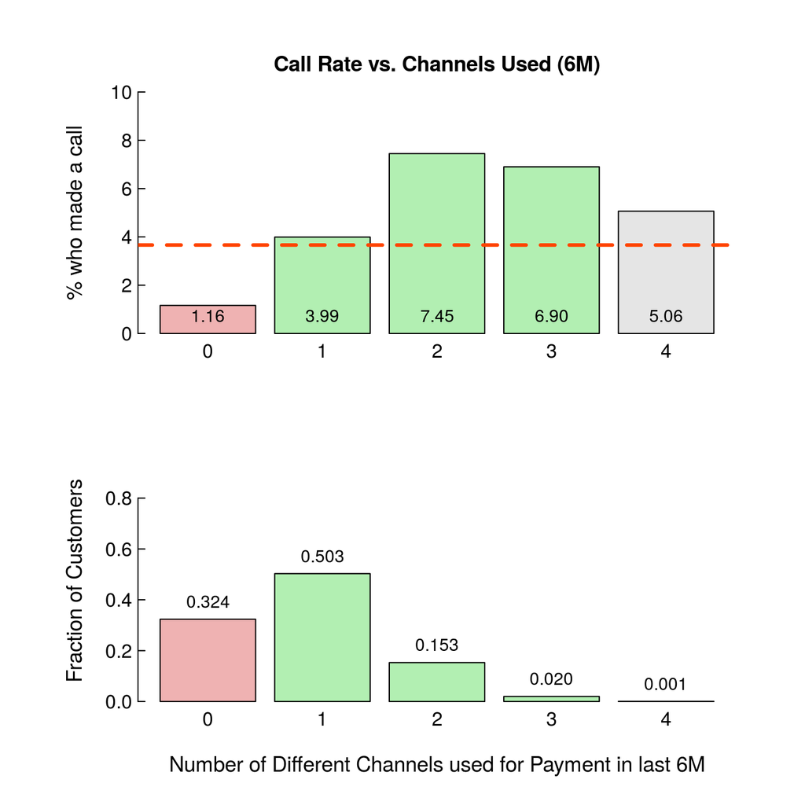

```r
par(gr_par_2)
layout(layout_1_2)
bp_col <- get_colors_vector(values = tmp[, 5], sd = tmp[, 6], nsigma = 2)

bp_x <- barplot(tmp[, 5], ylim = ylim_pct, col = bp_col, xlab = "", ylab = "% who made a call")
abline(base_rate, 0, lty = 2, col = "orangered", lwd = 3)
text(bp_x, bp_text_offset_pct, labels = sprintf("%.2f", tmp[, 5]), pos = 3, cex = 0.9)

barplot(tmp[, 3]/sum(tmp[, 3]), ylim = ylim_frac, col = bp_col,
        xlab = "Number of Different Channels used for Payment in last 6M", ylab = "Fraction of Customers")
text(bp_x, tmp[, 4] + bp_text_offset_frac, labels = sprintf("%.3f", tmp[, 4]), pos = 3, cex = 0.9)

par(fig = c(0, 1, 0, 1), mar = c(5, 4, 4, 1)+0.1, cex.axis = 1.0)
title("Call Rate vs. Channels Used (6M)", cex.main = 1.1, outer = FALSE, line = 3)
```

#### vs. Number of Payments through Channel 2 (6M)

Call Rate vs. CHANNEL2 (6M)

|  | 0 | 1 | tot | fraction | pct_of_1 | pct_unc |
| --- | --- | --- | --- | --- | --- | --- |
| 0 | 92042 | 2806 | 94848 | 0.729 | 2.958 | 0.055 |
| 1 | 7479 | 719 | 8198 | 0.063 | 8.770 | 0.312 |
| 2 | 3835 | 325 | 4160 | 0.032 | 7.812 | 0.416 |
| 3 | 3744 | 243 | 3987 | 0.031 | 6.095 | 0.379 |
| 4 | 4940 | 239 | 5179 | 0.040 | 4.615 | 0.292 |
| 5 | 4569 | 212 | 4781 | 0.037 | 4.434 | 0.298 |
| 6+ | 7943 | 181 | 8124 | 0.062 | 2.228 | 0.164 |

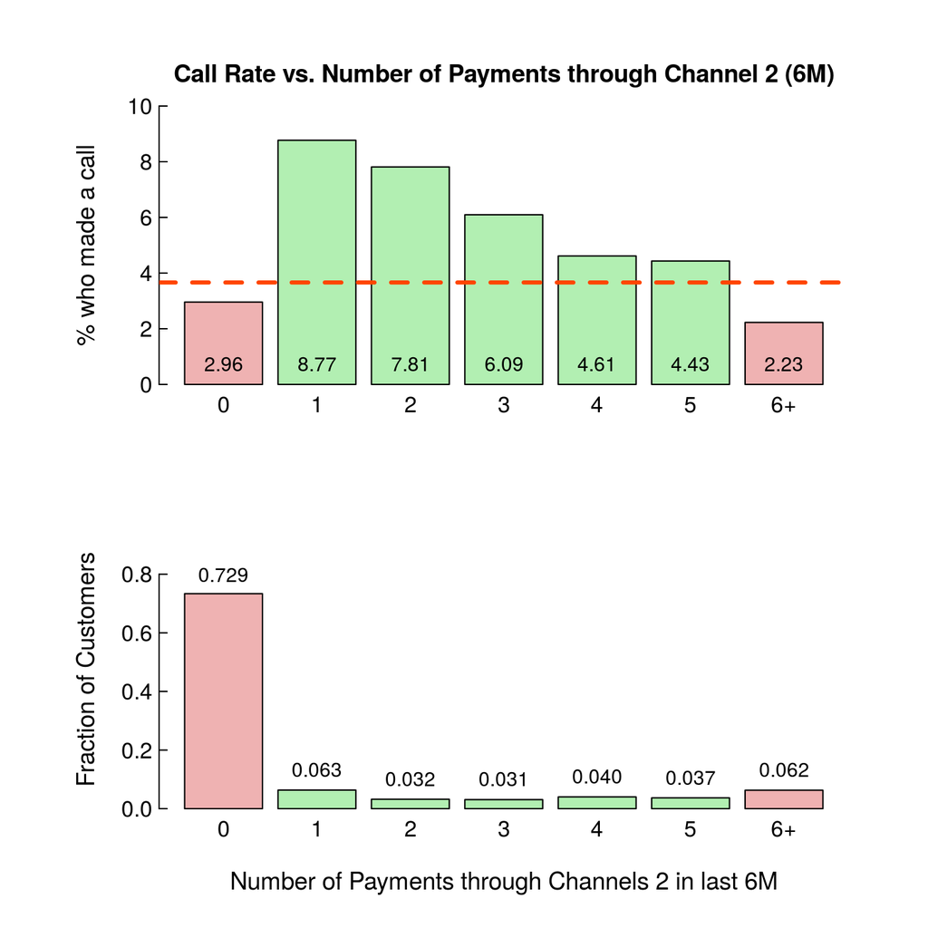

```r
par(gr_par_2)
layout(layout_1_2)
bp_col <- get_colors_vector(values = tmp[, 5], sd = tmp[, 6], nsigma = 2)

bp_x <- barplot(tmp[, 5], ylim = ylim_pct, col = bp_col, xlab = "", ylab = "% who made a call")
abline(base_rate, 0, lty = 2, col = "orangered", lwd = 3)
text(bp_x, bp_text_offset_pct, labels = sprintf("%.2f", tmp[, 5]), pos = 3, cex = 0.9)

barplot(tmp[, 3]/sum(tmp[, 3]), ylim = ylim_frac, col = bp_col,
        xlab = "Number of Payments through Channels 2 in last 6M", ylab = "Fraction of Customers")
text(bp_x, tmp[, 4] + bp_text_offset_frac, labels = sprintf("%.3f", tmp[, 4]), pos = 3, cex = 0.9)

par(fig = c(0, 1, 0, 1), mar = c(5, 4, 4, 1)+0.1, cex.axis = 1.0)
title("Call Rate vs. Number of Payments through Channel 2 (6M)", cex.main = 1.1, outer = FALSE, line = 3)
```

#### vs. Number of Payments through Channel 4 (6M)

Call Rate vs. CHANNEL4 (6M)

|  | 0 | 1 | tot | fraction | pct_of_1 | pct_unc |
| --- | --- | --- | --- | --- | --- | --- |
| 0 | 101616 | 1645 | 103261 | 0.794 | 1.593 | 0.039 |
| 1 | 13612 | 1091 | 14703 | 0.113 | 7.420 | 0.216 |
| 2 | 4692 | 564 | 5256 | 0.040 | 10.731 | 0.427 |
| 3 | 1933 | 324 | 2257 | 0.017 | 14.355 | 0.738 |
| 4 | 1057 | 327 | 1384 | 0.011 | 23.627 | 1.142 |
| 5 | 689 | 256 | 945 | 0.007 | 27.090 | 1.446 |
| 6+ | 953 | 518 | 1471 | 0.011 | 35.214 | 1.245 |

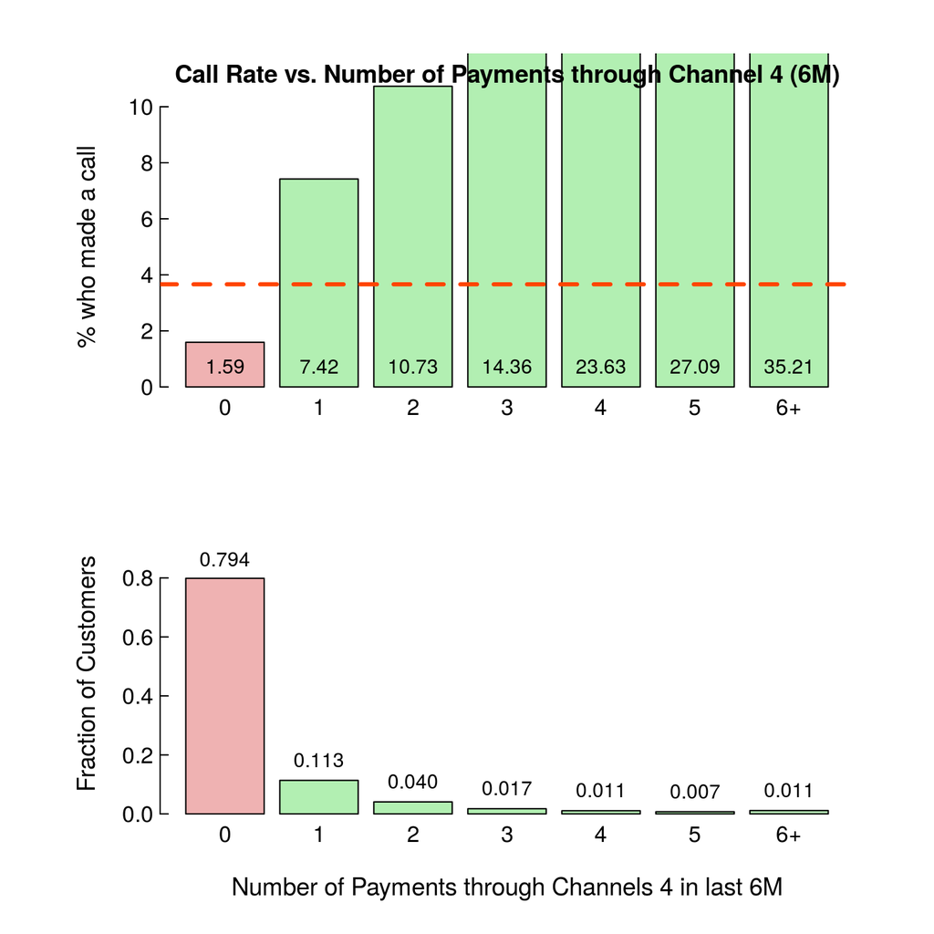

```r
par(gr_par_2)
layout(layout_1_2)
bp_col <- get_colors_vector(values = tmp[, 5], sd = tmp[, 6], nsigma = 2)

bp_x <- barplot(tmp[, 5], ylim = ylim_pct, col = bp_col, xlab = "", ylab = "% who made a call")
abline(base_rate, 0, lty = 2, col = "orangered", lwd = 3)
text(bp_x, bp_text_offset_pct, labels = sprintf("%.2f", tmp[, 5]), pos = 3, cex = 0.9)

barplot(tmp[, 3]/sum(tmp[, 3]), ylim = ylim_frac, col = bp_col,
        xlab = "Number of Payments through Channels 4 in last 6M", ylab = "Fraction of Customers")
text(bp_x, tmp[, 4] + bp_text_offset_frac, labels = sprintf("%.3f", tmp[, 4]), pos = 3, cex = 0.9)

par(fig = c(0, 1, 0, 1), mar = c(5, 4, 4, 1)+0.1, cex.axis = 1.0)
title("Call Rate vs. Number of Payments through Channel 4 (6M)", cex.main = 1.1, outer = FALSE, line = 3)
```

#### vs. Number of Payments (6M)

Call Rate vs. PAYMENTS (6M)

|  | 0 | 1 | tot | fraction | pct_of_1 | pct_unc |
| --- | --- | --- | --- | --- | --- | --- |
| 1 | 12226 | 988 | 13214 | 0.102 | 7.477 | 0.229 |
| 2 | 6974 | 470 | 7444 | 0.057 | 6.314 | 0.282 |
| 3 | 7751 | 345 | 8096 | 0.062 | 4.261 | 0.224 |
| 4 | 16264 | 545 | 16809 | 0.129 | 3.242 | 0.137 |
| 5 | 17588 | 556 | 18144 | 0.139 | 3.064 | 0.128 |
| 6 | 52999 | 1359 | 54358 | 0.418 | 2.500 | 0.067 |
| 7 | 6421 | 255 | 6676 | 0.051 | 3.820 | 0.235 |
| 8 | 1896 | 85 | 1981 | 0.015 | 4.291 | 0.455 |
| 9+ | 2433 | 122 | 2555 | 0.020 | 4.775 | 0.422 |

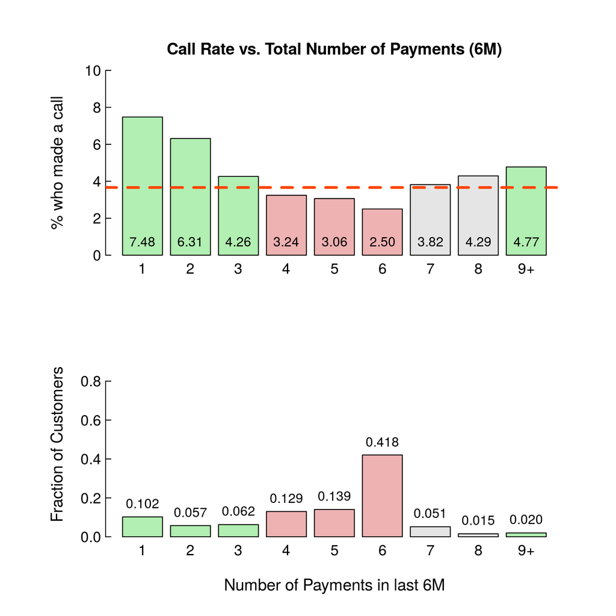

```r
par(gr_par_2)
layout(layout_1_2)
bp_col <- get_colors_vector(values = tmp[, 5], sd = tmp[, 6], nsigma = 2)

bp_x <- barplot(tmp[, 5], ylim = ylim_pct, col = bp_col, xlab = "", ylab = "% who made a call")
abline(base_rate, 0, lty = 2, col = "orangered", lwd = 3)
text(bp_x, bp_text_offset_pct, labels = sprintf("%.2f", tmp[, 5]), pos = 3, cex = 0.9)

barplot(tmp[, 3]/sum(tmp[, 3]), ylim = ylim_frac, col = bp_col,
        xlab = "Number of Payments in last 6M", ylab = "Fraction of Customers")
text(bp_x, tmp[, 4] + bp_text_offset_frac, labels = sprintf("%.3f", tmp[, 4]), pos = 3, cex = 0.9)

par(fig = c(0, 1, 0, 1), mar = c(5, 4, 4, 1)+0.1, cex.axis = 1.0)
title("Call Rate vs. Total Number of Payments (6M)", cex.main = 1.1, outer = FALSE, line = 3)
```

#### vs. Number of Different Channels used by Customer (3M)

Call Rate vs. Number of Different Channels used by Customer (3M)

|  | 0 | 1 | tot | fraction | pct_of_1 | pct_unc |
| --- | --- | --- | --- | --- | --- | --- |
| 0 | 52874 | 1378 | 54252 | 0.417 | 2.540 | 0.068 |
| 1 | 61555 | 2509 | 64064 | 0.492 | 3.916 | 0.077 |
| 2 | 10364 | 827 | 11191 | 0.086 | 7.390 | 0.247 |
| 3 | 517 | 50 | 567 | 0.004 | 8.818 | 1.191 |
| 4 | 12 | 0 | 12 | 0.000 | 0.000 | 0.000 |

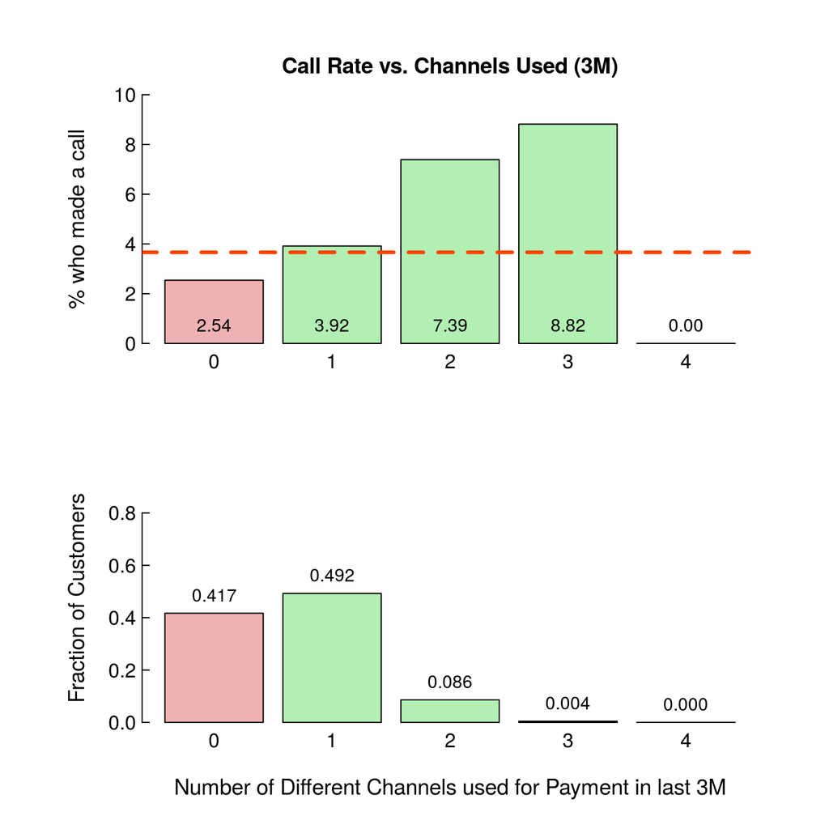

```r
par(gr_par_2)
layout(layout_1_2)
bp_col <- get_colors_vector(values = tmp[, 5], sd = tmp[, 6], nsigma = 2)

bp_x <- barplot(tmp[, 5], ylim = ylim_pct, col = bp_col, xlab = "", ylab = "% who made a call")
abline(base_rate, 0, lty = 2, col = "orangered", lwd = 3)
text(bp_x, bp_text_offset_pct, labels = sprintf("%.2f", tmp[, 5]), pos = 3, cex = 0.9)

barplot(tmp[, 3]/sum(tmp[, 3]), ylim = ylim_frac, col = bp_col,
        xlab = "Number of Different Channels used for Payment in last 3M", ylab = "Fraction of Customers")
text(bp_x, tmp[, 4] + bp_text_offset_frac, labels = sprintf("%.3f", tmp[, 4]), pos = 3, cex = 0.9)

par(fig = c(0, 1, 0, 1), mar = c(5, 4, 4, 1)+0.1, cex.axis = 1.0)
title("Call Rate vs. Channels Used (3M)", cex.main = 1.1, outer = FALSE, line = 3)
```

#### vs. Number of Payments through Channel 2 (3M)

Call Rate vs. CHANNEL2 (3M)

|  | 0 | 1 | tot | fraction | pct_of_1 | pct_unc |
| --- | --- | --- | --- | --- | --- | --- |
| 0 | 98315 | 3406 | 101721 | 0.782 | 3.348 | 0.056 |
| 1 | 8059 | 626 | 8685 | 0.067 | 7.208 | 0.278 |
| 2 | 6435 | 322 | 6757 | 0.052 | 4.765 | 0.259 |
| 3 | 11993 | 398 | 12391 | 0.095 | 3.212 | 0.158 |
| 4+ | 520 | 12 | 532 | 0.004 | 2.256 | 0.644 |

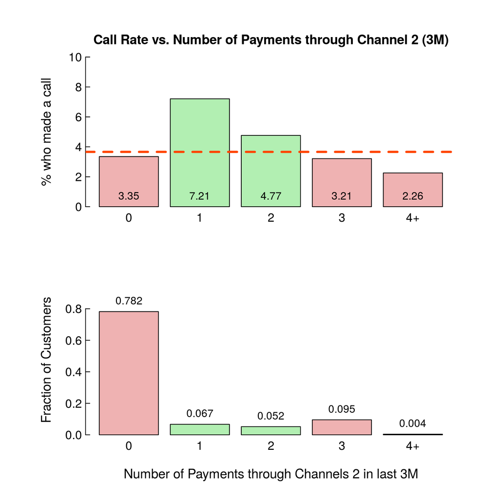

```r
par(gr_par_2)
layout(layout_1_2)
bp_col <- get_colors_vector(values = tmp[, 5], sd = tmp[, 6], nsigma = 2)

bp_x <- barplot(tmp[, 5], ylim = ylim_pct, col = bp_col, xlab = "", ylab = "% who made a call")
abline(base_rate, 0, lty = 2, col = "orangered", lwd = 3)
text(bp_x, bp_text_offset_pct, labels = sprintf("%.2f", tmp[, 5]), pos = 3, cex = 0.9)

barplot(tmp[, 3]/sum(tmp[, 3]), ylim = ylim_frac, col = bp_col,
        xlab = "Number of Payments through Channels 2 in last 3M", ylab = "Fraction of Customers")
text(bp_x, tmp[, 4] + bp_text_offset_frac, labels = sprintf("%.3f", tmp[, 4]), pos = 3, cex = 0.9)

par(fig = c(0, 1, 0, 1), mar = c(5, 4, 4, 1)+0.1, cex.axis = 1.0)
title("Call Rate vs. Number of Payments through Channel 2 (3M)", cex.main = 1.1, outer = FALSE, line = 3)
```

#### vs. Number of Payments through Channel 4 (3M)

Call Rate vs. CHANNEL4 (3M)

|  | 0 | 1 | tot | fraction | pct_of_1 | pct_unc |
| --- | --- | --- | --- | --- | --- | --- |
| 0 | 111328 | 2573 | 113901 | 0.876 | 2.259 | 0.044 |
| 1 | 9262 | 848 | 10110 | 0.078 | 8.388 | 0.276 |
| 2 | 2878 | 502 | 3380 | 0.026 | 14.852 | 0.612 |
| 3 | 1547 | 722 | 2269 | 0.017 | 31.820 | 0.978 |
| 4+ | 307 | 119 | 426 | 0.003 | 27.934 | 2.174 |

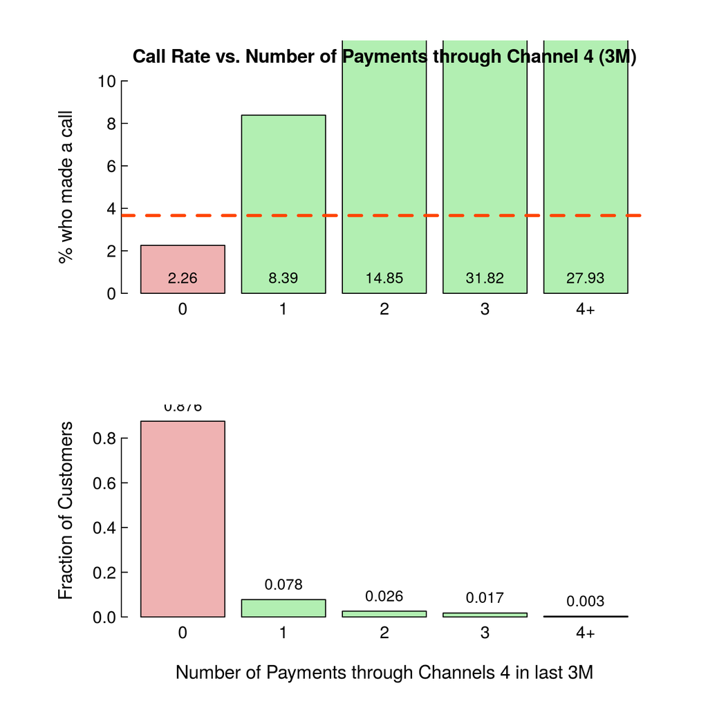

```r
par(gr_par_2)
layout(layout_1_2)
bp_col <- get_colors_vector(values = tmp[, 5], sd = tmp[, 6], nsigma = 2)

bp_x <- barplot(tmp[, 5], ylim = ylim_pct, col = bp_col, xlab = "", ylab = "% who made a call")
abline(base_rate, 0, lty = 2, col = "orangered", lwd = 3)
text(bp_x, bp_text_offset_pct, labels = sprintf("%.2f", tmp[, 5]), pos = 3, cex = 0.9)

barplot(tmp[, 3]/sum(tmp[, 3]), ylim = ylim_frac, col = bp_col,
        xlab = "Number of Payments through Channels 4 in last 3M", ylab = "Fraction of Customers")
text(bp_x, tmp[, 4] + bp_text_offset_frac, labels = sprintf("%.3f", tmp[, 4]), pos = 3, cex = 0.9)

par(fig = c(0, 1, 0, 1), mar = c(5, 4, 4, 1)+0.1, cex.axis = 1.0)
title("Call Rate vs. Number of Payments through Channel 4 (3M)", cex.main = 1.1, outer = FALSE, line = 3)
```

#### vs. Number of Payments (3M)

Call Rate vs. PAYMENTS (3M)

|  | 0 | 1 | tot | fraction | pct_of_1 | pct_unc |
| --- | --- | --- | --- | --- | --- | --- |
| 0 | 12026 | 1068 | 13094 | 0.101 | 8.156 | 0.239 |
| 1 | 16367 | 775 | 17142 | 0.132 | 4.521 | 0.159 |
| 2 | 16779 | 586 | 17365 | 0.133 | 3.375 | 0.137 |
| 3 | 70920 | 1919 | 72839 | 0.560 | 2.635 | 0.059 |
| 4 | 6758 | 274 | 7032 | 0.054 | 3.896 | 0.231 |
| 5+ | 2472 | 142 | 2614 | 0.020 | 5.432 | 0.443 |

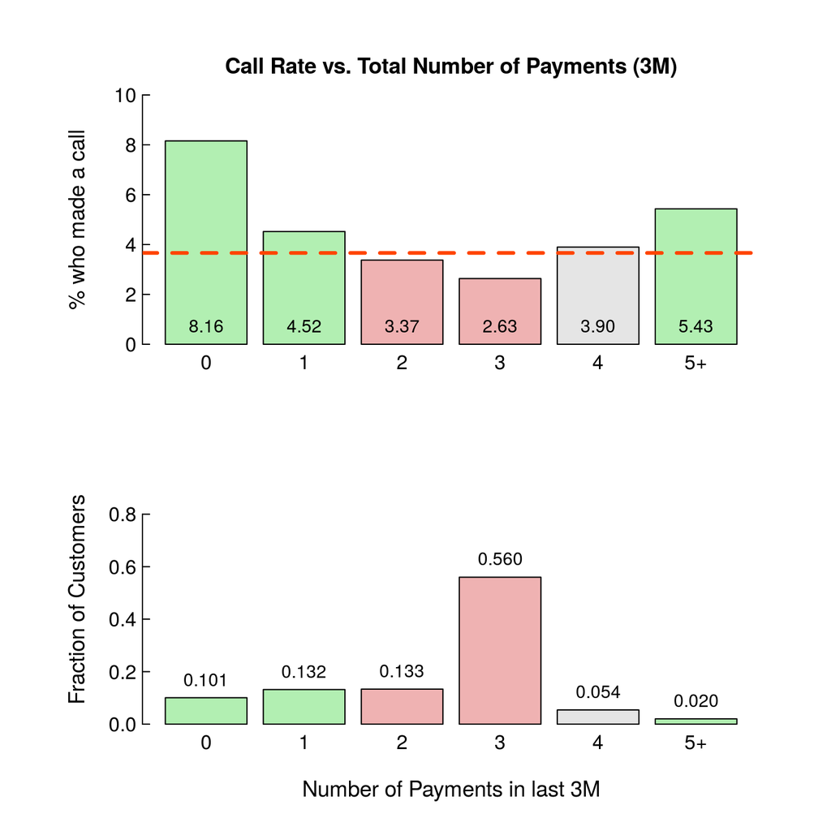

```r
par(gr_par_2)
layout(layout_1_2)
bp_col <- get_colors_vector(values = tmp[, 5], sd = tmp[, 6], nsigma = 2)

bp_x <- barplot(tmp[, 5], ylim = ylim_pct, col = bp_col, xlab = "", ylab = "% who made a call")
abline(base_rate, 0, lty = 2, col = "orangered", lwd = 3)
text(bp_x, bp_text_offset_pct, labels = sprintf("%.2f", tmp[, 5]), pos = 3, cex = 0.9)

barplot(tmp[, 3]/sum(tmp[, 3]), ylim = ylim_frac, col = bp_col,
        xlab = "Number of Payments in last 3M", ylab = "Fraction of Customers")
text(bp_x, tmp[, 4] + bp_text_offset_frac, labels = sprintf("%.3f", tmp[, 4]), pos = 3, cex = 0.9)

par(fig = c(0, 1, 0, 1), mar = c(5, 4, 4, 1)+0.1, cex.axis = 1.0)
title("Call Rate vs. Total Number of Payments (3M)", cex.main = 1.1, outer = FALSE, line = 3)
```

#### vs. Age (group)

Age

|  | 0 | 1 | tot | fraction | pct_of_1 | pct_unc |
| --- | --- | --- | --- | --- | --- | --- |
| [15,25) | 4213 | 203 | 4416 | 0.034 | 4.597 | 0.315 |
| [25,30) | 8803 | 326 | 9129 | 0.070 | 3.571 | 0.194 |
| [30,35) | 11477 | 307 | 11784 | 0.091 | 2.605 | 0.147 |
| [35,40) | 12329 | 359 | 12688 | 0.098 | 2.829 | 0.147 |
| [40,45) | 13967 | 473 | 14440 | 0.111 | 3.276 | 0.148 |
| [45,50) | 14873 | 557 | 15430 | 0.119 | 3.610 | 0.150 |
| [50,55) | 16526 | 676 | 17202 | 0.132 | 3.930 | 0.148 |
| [55,60) | 15079 | 592 | 15671 | 0.120 | 3.778 | 0.152 |
| [60,65) | 11629 | 470 | 12099 | 0.093 | 3.885 | 0.176 |
| [65,70) | 8068 | 356 | 8424 | 0.065 | 4.226 | 0.219 |
| [70,75) | 4606 | 217 | 4823 | 0.037 | 4.499 | 0.298 |
| [75,100) | 3752 | 228 | 3980 | 0.031 | 5.729 | 0.368 |

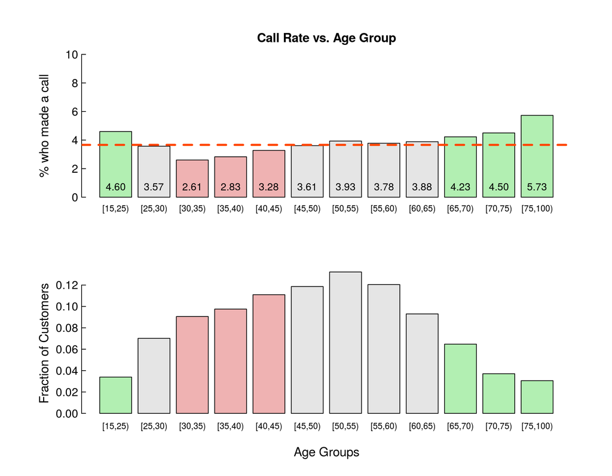

```r
# grp_names <- paste(age_breaks[-length(age_breaks)], age_breaks[-1], sep = "-")
par(gr_par_2)
layout(layout_1_2)
bp_col <- get_colors_vector(values = tmp[, 5], sd = tmp[, 6], nsigma = 2)

bp_x <- barplot(tmp[, 5], ylim = ylim_pct, col = bp_col, xlab = "", ylab = "% who made a call", cex.names = 0.75)
abline(base_rate, 0, lty = 2, col = "orangered", lwd = 3)
text(bp_x, bp_text_offset_pct, labels = sprintf("%.2f", tmp[, 5]), pos = 3, cex = 0.9)

barplot(tmp[, 3]/sum(tmp[, 3]), col = bp_col,
        xlab = "Age Groups", ylab = "Fraction of Customers", cex.names = 0.75)

par(fig = c(0, 1, 0, 1), mar = c(5, 4, 4, 1)+0.1, cex.axis = 1.0)
title("Call Rate vs. Age Group", cex.main = 1.1, outer = FALSE, line = 3)
```

#### vs. Tenure (group)

Tenure

|  | 0 | 1 | tot | fraction | pct_of_1 | pct_unc |
| --- | --- | --- | --- | --- | --- | --- |
| [0,2) | 19409 | 1146 | 20555 | 0.158 | 5.575 | 0.160 |
| [2,4) | 17273 | 839 | 18112 | 0.139 | 4.632 | 0.156 |
| [4,6) | 15703 | 671 | 16374 | 0.126 | 4.098 | 0.155 |
| [6,8) | 19096 | 530 | 19626 | 0.151 | 2.700 | 0.116 |
| [8,10) | 14430 | 389 | 14819 | 0.114 | 2.625 | 0.131 |
| [10,12) | 9113 | 288 | 9401 | 0.072 | 3.064 | 0.178 |
| [12,14) | 5570 | 193 | 5763 | 0.044 | 3.349 | 0.237 |
| [14,16) | 8058 | 225 | 8283 | 0.064 | 2.716 | 0.179 |
| [16,18) | 5418 | 116 | 5534 | 0.043 | 2.096 | 0.193 |
| [18,20) | 2745 | 74 | 2819 | 0.022 | 2.625 | 0.301 |
| [20,30) | 5959 | 193 | 6152 | 0.047 | 3.137 | 0.222 |
| [30,40) | 1849 | 69 | 1918 | 0.015 | 3.597 | 0.425 |
| [40,99) | 699 | 31 | 730 | 0.006 | 4.247 | 0.746 |

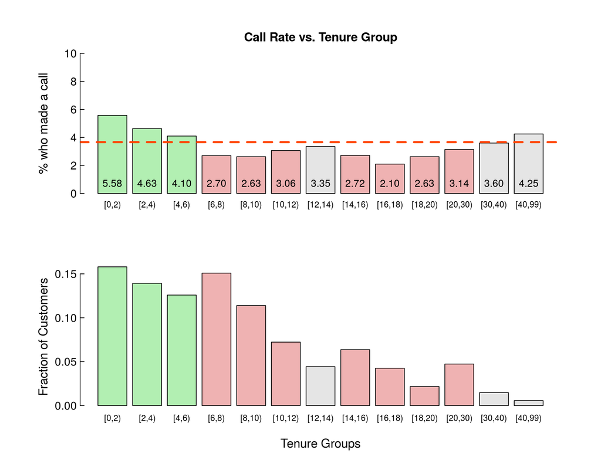

```r
# grp_names <- paste(tenure_breaks[-length(tenure_breaks)], tenure_breaks[-1], sep = "-")
par(gr_par_2)
layout(layout_1_2)
bp_col <- get_colors_vector(values = tmp[, 5], sd = tmp[, 6], nsigma = 2)

bp_x <- barplot(tmp[, 5], ylim = ylim_pct, col = bp_col, xlab = "", ylab = "% who made a call", cex.names = 0.75)
abline(base_rate, 0, lty = 2, col = "orangered", lwd = 3)
text(bp_x, bp_text_offset_pct, labels = sprintf("%.2f", tmp[, 5]), pos = 3, cex = 0.9)

barplot(tmp[, 3]/sum(tmp[, 3]), xlab = "Tenure Groups", ylab = "Fraction of Customers", cex.names = 0.75, col = bp_col)

par(fig = c(0, 1, 0, 1), mar = c(5, 4, 4, 1)+0.1, cex.axis = 1.0)
title("Call Rate vs. Tenure Group", cex.main = 1.1, outer = FALSE, line = 3)
```

#### vs. Tenure and Age Groups combined

Heatmap color coded on the average *Call Rate* for each group divided by the *base rate*.  
Green means above average, red below average.

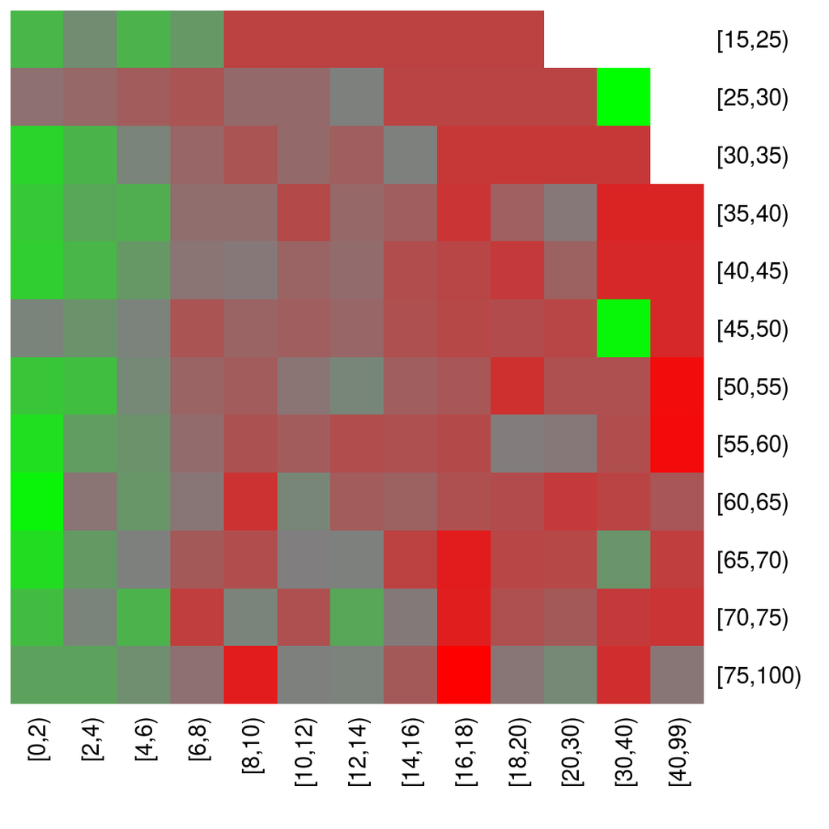

# APPENDIX

## Data Sets Preparation

Removing

- `EVENT1_30_FLAG` because it has the same value for all customers in this dataset.

```r
# main$Nch_6M <- Nch_6M_by_customer
# main$Nch_3M <- Nch_3M_by_customer
main$EVENT1_30_FLAG <- NULL

# main.imputed$Nch_6M <- Nch_6M_by_customer
# main.imputed$Nch_3M <- Nch_3M_by_customer
main.imputed$EVENT1_30_FLAG <- NULL
```

### Summary of data set variations used in modeling

Code and details of datasets preparation are illustrated in following sections.  
This table summarizes variable sets for the different alternative datasets.

- **YES**: included in its original form (aside from minor fixes detailed in the report).
- **YES^**: included with imputed missing values.
- **Y**: included but removing *missing values*.
- **–**: NOT included.

|  | v0a | v0b | v1 | v2 | v3 | v4 | v5 |
| --- | --- | --- | --- | --- | --- | --- | --- |
| **ORIGINAL VARIABLES** |  |  |  |  |  |  |  |
| *DATE_FOR* | YES | – | – | – | – | – | – |
| *RTD_ST_CD* | YES | YES | – | – | – | – | – |
| *CustomerSegment* | YES | YES | YES | YES | YES | YES | YES |
| *Tenure* | YES | YES | YES | YES | YES | YES | YES |
| *Age* | YES | YES | YES | YES | YES | YES | YES |
| *MART_STATUS* | YES | YES | YES | YES | YES | YES | YES |
| *GENDER* | YES | YES | YES | YES | YES | YES | YES |
| *CHANNELx_6M* | Y | Y | – | Y | Y | – | YES^ |
| *METHOD1_6M* | Y | Y | – | Y | Y | – | YES^ |
| *PAYMENTS_6M* | Y | Y | – | Y | Y | – | YES^ |
| *CHANNELx_3M* | YES | YES | YES | YES | YES | YES | YES |
| *METHOD1_3M* | YES | YES | YES | YES | YES | YES | YES |
| *PAYMENTS_3M* | YES | YES | YES | YES | YES | YES | YES |
| *RECENT_PAYMENT* | Y | Y | Y | Y | Y | Y | YES^ |
| *NOT_DI_3M* | YES | YES | YES | YES | YES | YES | YES |
| *NOT_DI_6M* | YES | YES | YES | YES | YES | YES | YES |
| *EVENT1_30_FLAG* | – | – | – | – | – | – | – |
| *EVENT2_90_SUM* | YES | YES | YES | YES | YES | YES | YES |
| *LOGINS* | YES | YES | YES | YES | YES | YES | YES |
| *POLICYPURCHASECHANNEL* | YES | YES | YES | YES | YES | YES | YES |
| **NEW VARIABLES** |  |  |  |  |  |  |  |
| *Age_grp* | – | – | – | – | YES | YES | – |
| *Tenure_grp* | – | – | – | – | YES | YES | – |
| *Nch_6M* | – | – | – | – | YES | YES | – |
| *Nch_3M* | – | – | – | – | YES | YES | – |

### Variables Set #0a

The 1-st data set we modeled is the original one with the following changes:

- **Excluding** variables:
  - `EVENT1_30_FLAG` (because constant)
- Removing the **incomplete cases** (i.e. 809 customers)

```r
# "EVENT1_30_FLAG"

data0a.used_vars <- c("Call_Flag",
                     "DATE_FOR", "RTD_ST_CD",
                     "CHANNEL1_6M", "CHANNEL2_6M", "CHANNEL3_6M", "CHANNEL4_6M", "CHANNEL5_6M", "METHOD1_6M", "PAYMENTS_6M",
                     "CustomerSegment", "Tenure",
                     "Age", "MART_STATUS", "GENDER",
                     "CHANNEL1_3M", "CHANNEL2_3M", "CHANNEL3_3M", "CHANNEL4_3M", "CHANNEL5_3M", "METHOD1_3M", "PAYMENTS_3M",
                     "RECENT_PAYMENT",
                     "NOT_DI_3M", "NOT_DI_6M",
                     "EVENT2_90_SUM",
                     "LOGINS",
                     "POLICYPURCHASECHANNEL")

data0a.df_for_fit <- main[, data0a.used_vars]
data0a.df_for_fit <- data0a.df_for_fit[complete.cases(data0a.df_for_fit), ]

data0a.seed <- 10471
set.seed(data0a.seed)
data0a.split <- sample.split(data0a.df_for_fit$Call_Flag, SplitRatio = 0.7)
data0a.train <- subset(data0a.df_for_fit, data0a.split == TRUE)
data0a.test  <- subset(data0a.df_for_fit, data0a.split == FALSE)

data0a.pkg <- list(used_vars = data0a.used_vars,
                  df_for_fit = data0a.df_for_fit,
                  seed = data0a.seed,
                  split = data0a.split,
                  train = data0a.train,
                  test = data0a.test)
saveRDS(data0a.pkg, file = "./data0a_packed.RDS")
```

### Variables Set #0b

The 1-st data set we modeled is the original one with the following changes:

- **Excluding** variables:
  - `EVENT1_30_FLAG` (because constant)
  - `DATE_FOR`
- Removing the **incomplete cases** (i.e. 809 customers)

```r
# "EVENT1_30_FLAG"
# "DATE_FOR"

data0b.used_vars <- c("Call_Flag",
                     "RTD_ST_CD",
                     "CHANNEL1_6M", "CHANNEL2_6M", "CHANNEL3_6M", "CHANNEL4_6M", "CHANNEL5_6M", "METHOD1_6M", "PAYMENTS_6M",
                     "CustomerSegment", "Tenure",
                     "Age", "MART_STATUS", "GENDER",
                     "CHANNEL1_3M", "CHANNEL2_3M", "CHANNEL3_3M", "CHANNEL4_3M", "CHANNEL5_3M", "METHOD1_3M", "PAYMENTS_3M",
                     "RECENT_PAYMENT",
                     "NOT_DI_3M", "NOT_DI_6M",
                     "EVENT2_90_SUM",
                     "LOGINS",
                     "POLICYPURCHASECHANNEL")

data0b.df_for_fit <- main[, data0b.used_vars]
data0b.df_for_fit <- data0b.df_for_fit[complete.cases(data0b.df_for_fit), ]

data0b.seed <- 10471
set.seed(data0b.seed)
data0b.split <- sample.split(data0b.df_for_fit$Call_Flag, SplitRatio = 0.7)
data0b.train <- subset(data0b.df_for_fit, data0b.split == TRUE)
data0b.test  <- subset(data0b.df_for_fit, data0b.split == FALSE)

data0b.pkg <- list(used_vars = data0b.used_vars,
                  df_for_fit = data0b.df_for_fit,
                  seed = data0b.seed,
                  split = data0b.split,
                  train = data0b.train,
                  test = data0b.test)
saveRDS(data0b.pkg, file = "./data0b_packed.RDS")
```

### Variables Set #1

The 1-st data set we modeled is the original one with the following changes:

- **Excluding** variables:
  - `EVENT1_30_FLAG` (because constant)
  - `DATE_FOR`
  - `RTD_ST_CD`
  - All `CHANNEL*_6M` and `PAYMENTS_6M` (those with `NA`).
- Removing the **incomplete cases** (i.e. 809 customers)

```r
# "DATE_FOR", "RTD_ST_CD",
# "CHANNEL1_6M", "CHANNEL2_6M", "CHANNEL3_6M", "CHANNEL4_6M", "CHANNEL5_6M", "METHOD1_6M", "PAYMENTS_6M",
# "EVENT1_30_FLAG"

data1.used_vars <- c("Call_Flag",
                     "CustomerSegment", "Tenure",
                     "Age", "MART_STATUS", "GENDER",
                     "CHANNEL1_3M", "CHANNEL2_3M", "CHANNEL3_3M", "CHANNEL4_3M", "CHANNEL5_3M", "METHOD1_3M", "PAYMENTS_3M",
                     "RECENT_PAYMENT",
                     "NOT_DI_3M", "NOT_DI_6M",
                     "EVENT2_90_SUM",
                     "LOGINS",
                     "POLICYPURCHASECHANNEL")

data1.df_for_fit <- main[, data1.used_vars]
data1.df_for_fit <- data1.df_for_fit[complete.cases(data1.df_for_fit), ]

data1.seed <- 2471
set.seed(data1.seed)
data1.split <- sample.split(data1.df_for_fit$Call_Flag, SplitRatio = 0.7)
data1.train <- subset(data1.df_for_fit, data1.split == TRUE)
data1.test  <- subset(data1.df_for_fit, data1.split == FALSE)

data1.pkg <- list(used_vars = data1.used_vars,
                  df_for_fit = data1.df_for_fit,
                  seed = data1.seed,
                  split = data1.split,
                  train = data1.train,
                  test = data1.test)
saveRDS(data1.pkg, file = "./data1_packed.RDS")
```

### Variables Set #2

Based on the original variables, with the following changes:

- **Excluding** variables:
  - `EVENT1_30_FLAG` (because constant)
  - `DATE_FOR`
  - `RTD_ST_CD`
- Removing the **incomplete cases** (i.e. 809 customers)

```r
# "DATE_FOR", "RTD_ST_CD",
# "EVENT1_30_FLAG"
# "Age_grp",
# "Tenure_grp",
# "Nch_6M",
# "Nch_3M")

data2.used_vars <- c("Call_Flag",
                     "CustomerSegment", "Tenure",
                     "Age", "MART_STATUS", "GENDER",
                     "CHANNEL1_6M", "CHANNEL2_6M", "CHANNEL3_6M", "CHANNEL4_6M", "CHANNEL5_6M", "METHOD1_6M", "PAYMENTS_6M",
                     "CHANNEL1_3M", "CHANNEL2_3M", "CHANNEL3_3M", "CHANNEL4_3M", "CHANNEL5_3M", "METHOD1_3M", "PAYMENTS_3M",
                     "RECENT_PAYMENT",
                     "NOT_DI_3M", "NOT_DI_6M",
                     "EVENT2_90_SUM",
                     "LOGINS",
                     "POLICYPURCHASECHANNEL")

data2.df_for_fit <- main[, data2.used_vars] %>% filter( . , !is.na(PAYMENTS_6M))
# data2.df_for_fit <- data2.df_for_fit[complete.cases(data2.df_for_fit), ]

data2.seed <- 2901
set.seed(data2.seed)
data2.split <- sample.split(data2.df_for_fit$Call_Flag, SplitRatio = 0.7)
data2.train <- subset(data2.df_for_fit, data2.split == TRUE)
data2.test  <- subset(data2.df_for_fit, data2.split == FALSE)

data2.pkg <- list(used_vars = data2.used_vars,
                  df_for_fit = data2.df_for_fit,
                  seed = data2.seed,
                  split = data2.split,
                  train = data2.train,
                  test = data2.test)
saveRDS(data2.pkg, file = "./data2_packed.RDS")
```

### Variables Set #3

Based on the original variables, with the following changes:

- **Excluding** variables:
  - `EVENT1_30_FLAG` (because constant)
  - `DATE_FOR`
  - `RTD_ST_CD`
- **Adding** variables:
  - `Age_grp`
  - `Tenure_grp`
  - `Nch_6M`
  - `Nch_3M`
- Removing the **incomplete cases** (i.e. 809 customers)

```r
# "DATE_FOR", "RTD_ST_CD",
# "EVENT1_30_FLAG"

data3.used_vars <- c("Call_Flag",
                     "CustomerSegment", "Tenure",
                     "Age", "MART_STATUS", "GENDER",
                     "CHANNEL1_6M", "CHANNEL2_6M", "CHANNEL3_6M", "CHANNEL4_6M", "CHANNEL5_6M", "METHOD1_6M", "PAYMENTS_6M",
                     "CHANNEL1_3M", "CHANNEL2_3M", "CHANNEL3_3M", "CHANNEL4_3M", "CHANNEL5_3M", "METHOD1_3M", "PAYMENTS_3M",
                     "RECENT_PAYMENT",
                     "NOT_DI_3M", "NOT_DI_6M",
                     "EVENT2_90_SUM",
                     "LOGINS",
                     "POLICYPURCHASECHANNEL",
                     "Age_grp",
                     "Tenure_grp",
                     "Nch_6M",
                     "Nch_3M")

data3.df_for_fit <- main[, data3.used_vars] %>% filter( . , !is.na(PAYMENTS_6M))
# data3.df_for_fit <- data3.df_for_fit[complete.cases(data3.df_for_fit), ]

data3.seed <- 3301
set.seed(data3.seed)
data3.split <- sample.split(data3.df_for_fit$Call_Flag, SplitRatio = 0.7)
data3.train <- subset(data3.df_for_fit, data3.split == TRUE)
data3.test  <- subset(data3.df_for_fit, data3.split == FALSE)

data3.pkg <- list(used_vars = data3.used_vars,
                  df_for_fit = data3.df_for_fit,
                  seed = data3.seed,
                  split = data3.split,
                  train = data3.train,
                  test = data3.test)
saveRDS(data3.pkg, file = "./data3_packed.RDS")
```

### Variables Set #4

Based on the original variables, with the following changes:

- **Excluding** the variables:
  - `EVENT1_30_FLAG` (because constant)
  - `DATE_FOR`
  - `RTD_ST_CD`
  - All `CHANNEL*_6M` and `PAYMENTS_6M` (those with `NA`).
- **Adding** variables:
  - `Age_grp`
  - `Tenure_grp`
  - `Nch_6M`
  - `Nch_3M`

```r
# "DATE_FOR", "RTD_ST_CD",
# "CHANNEL1_6M", "CHANNEL2_6M", "CHANNEL3_6M", "CHANNEL4_6M", "CHANNEL5_6M", "METHOD1_6M", "PAYMENTS_6M",
# "EVENT1_30_FLAG"

data4.used_vars <- c("Call_Flag",
                     "CustomerSegment", "Tenure",
                     "Age", "MART_STATUS", "GENDER",
                     "CHANNEL1_3M", "CHANNEL2_3M", "CHANNEL3_3M", "CHANNEL4_3M", "CHANNEL5_3M", "METHOD1_3M", "PAYMENTS_3M",
                     "RECENT_PAYMENT",
                     "NOT_DI_3M", "NOT_DI_6M",
                     "EVENT2_90_SUM",
                     "LOGINS",
                     "POLICYPURCHASECHANNEL",
                     "Age_grp",
                     "Tenure_grp",
                     "Nch_6M",
                     "Nch_3M")

data4.df_for_fit <- main[, data4.used_vars]
data4.df_for_fit <- data4.df_for_fit[complete.cases(data4.df_for_fit), ]

data4.seed <- 4401
set.seed(data4.seed)
data4.split <- sample.split(data4.df_for_fit$Call_Flag, SplitRatio = 0.7)
data4.train <- subset(data4.df_for_fit, data4.split == TRUE)
data4.test  <- subset(data4.df_for_fit, data4.split == FALSE)

data4.pkg <- list(used_vars = data4.used_vars,
                  df_for_fit = data4.df_for_fit,
                  seed = data4.seed,
                  split = data4.split,
                  train = data4.train,
                  test = data4.test)
saveRDS(data4.pkg, file = "./data4_packed.RDS")
```

### Variables Set #5

Based on the **dataset with imputed missing values** (`main.imputed`), using the original variables set with the following changes:

- **Excluding** the variables:
  - `EVENT1_30_FLAG` (because constant)
  - `DATE_FOR`
  - `RTD_ST_CD`

```r
# "DATE_FOR", "RTD_ST_CD",
# "EVENT1_30_FLAG"
# "Age_grp",
# "Tenure_grp",
# "Nch_6M",
# "Nch_3M")

data5.used_vars <- c("Call_Flag",
                     "CustomerSegment", "Tenure",
                     "Age", "MART_STATUS", "GENDER",
                     "CHANNEL1_6M", "CHANNEL2_6M", "CHANNEL3_6M", "CHANNEL4_6M", "CHANNEL5_6M", "METHOD1_6M", "PAYMENTS_6M",
                     "CHANNEL1_3M", "CHANNEL2_3M", "CHANNEL3_3M", "CHANNEL4_3M", "CHANNEL5_3M", "METHOD1_3M", "PAYMENTS_3M",
                     "RECENT_PAYMENT",
                     "NOT_DI_3M", "NOT_DI_6M",
                     "EVENT2_90_SUM",
                     "LOGINS",
                     "POLICYPURCHASECHANNEL")

data5.df_for_fit <- main.imputed[, data5.used_vars]
data5.df_for_fit <- data5.df_for_fit[complete.cases(data5.df_for_fit), ]

data5.seed <- 5501
set.seed(data5.seed)
data5.split <- sample.split(data5.df_for_fit$Call_Flag, SplitRatio = 0.7)
data5.train <- subset(data5.df_for_fit, data5.split == TRUE)
data5.test  <- subset(data5.df_for_fit, data5.split == FALSE)

data5.pkg <- list(used_vars = data5.used_vars,
                  df_for_fit = data5.df_for_fit,
                  seed = data5.seed,
                  split = data5.split,
                  train = data5.train,
                  test = data5.test)
saveRDS(data5.pkg, file = "./data5_packed.RDS")
```

## R Session Info

```r
sessionInfo()
# R version 3.1.3 (2015-03-09)
# Platform: x86_64-pc-linux-gnu (64-bit)
# Running under: Ubuntu 14.04.3 LTS
#
# locale:
#  [1] LC_CTYPE=en_US.UTF-8       LC_NUMERIC=C               LC_TIME=en_US.UTF-8
#  [4] LC_COLLATE=C               LC_MONETARY=en_US.UTF-8    LC_MESSAGES=en_US.UTF-8
#  [7] LC_PAPER=en_US.UTF-8       LC_NAME=C                  LC_ADDRESS=C
# [10] LC_TELEPHONE=C             LC_MEASUREMENT=en_US.UTF-8 LC_IDENTIFICATION=C
#
# attached base packages:
# [1] stats     graphics  grDevices utils     datasets  methods   base
#
# other attached packages:
#  [1] earth_4.3.0       plotmo_3.1.4      TeachingDemos_2.9 plotrix_3.5-12    tree_1.0-36
#  [6] rpart.plot_1.5.2  rpart_4.1-9       caret_6.0-52      lattice_0.20-31   ROCR_1.0-7
# [11] gplots_2.17.0     caTools_1.17.1    MASS_7.3-43       ggplot2_1.0.1     lubridate_1.3.3
# [16] dplyr_0.4.2       knitr_1.11
#
# loaded via a namespace (and not attached):
#  [1] BradleyTerry2_1.0-6 DBI_0.3.1           KernSmooth_2.23-14  Matrix_1.2-2
#  [5] MatrixModels_0.4-1  R6_2.1.1            Rcpp_0.12.0         SparseM_1.7
#  [9] assertthat_0.1      bitops_1.0-6        brglm_0.5-9         car_2.0-25
# [13] codetools_0.2-11    colorspace_1.2-6    digest_0.6.8        evaluate_0.7.2
# [17] foreach_1.4.2       formatR_1.2         gdata_2.17.0        grid_3.1.3
# [21] gtable_0.1.2        gtools_3.5.0        highr_0.5           htmltools_0.2.6
# [25] iterators_1.0.7     lme4_1.1-9          magrittr_1.5        memoise_0.2.1
# [29] mgcv_1.8-6          minqa_1.2.4         munsell_0.4.2       nlme_3.1-122
# [33] nloptr_1.0.4        nnet_7.3-9          parallel_3.1.3      pbkrtest_0.4-2
# [37] plyr_1.8.3          proto_0.3-10        quantreg_5.18       reshape2_1.4.1
# [41] rmarkdown_0.7       scales_0.3.0        splines_3.1.3       stats4_3.1.3
# [45] stringi_0.5-5       stringr_1.0.0       tools_3.1.3         yaml_2.1.13
```